# **Brain Stroke Prediction Using Machine Learning and Data Science.**

### **Importing Necessary Libraries.**

```python
#pip install autoviz
#pip install pandas
#pip install matplotlib.pyplot
#pip install seaborn
#pip install numpy
#pip install sklearn
#pip install collections
#pip install ipywidgets
#pip install imblearn
#pip install statsmodels
#pip install warnings
```

```python
import pandas as pd
import matplotlib.pyplot as plt
%matplotlib inline
plt.style.use('dark_background')
import seaborn as sns
import numpy as np
from sklearn.model_selection import train_test_split
from sklearn.metrics import confusion_matrix,classification_report, accuracy_score, precision_recall_curve,precision_score,recall_score,f1_score, roc_auc_score, roc_curve, auc
from sklearn.preprocessing import StandardScaler
from statsmodels.stats.outliers_influence import variance_inflation_factor
from imblearn.over_sampling import RandomOverSampler,SMOTE
from imblearn.combine import SMOTETomek
from collections import Counter
from sklearn.model_selection import GridSearchCV, RandomizedSearchCV
import warnings
warnings.filterwarnings(action='ignore')
from sklearn import tree
import autoviz
from autoviz.AutoViz_Class import AutoViz_Class
#for interactive console
import ipywidgets
import ipywidgets as widgets
from ipywidgets import interact
from ipywidgets import interact_manual
```

### **Importing and Skimming the Data Set.**

The Data set consists of 40000+ entries of Patients Regarding Brain Stroke symptoms. There are total of 12 columns including target_column.

1. id
2. gender
3. age
4. hypertension
5. heart_disease
6. ever_married
7. work_type
8. Residence_type
9. avg_glucose_level
10. bmi
11. smoking_status
12. stroke(target_column)

```python
dodge = pd.read_csv('train_strokes.csv')
```

```python
# head() helps us to view the first 5 entries in our dataset.

dodge.head()
```

|  | id | gender | age | hypertension | heart_disease | ever_married | work_type | Residence_type | avg_glucose_level | bmi | smoking_status | stroke |
| --- | --- | --- | --- | --- | --- | --- | --- | --- | --- | --- | --- | --- |
| 0 | 30669 | Male | 3.0 | 0 | 0 | No | children | Rural | 95.12 | 18.0 | NaN | 0 |
| 1 | 30468 | Male | 58.0 | 1 | 0 | Yes | Private | Urban | 87.96 | 39.2 | never smoked | 0 |
| 2 | 16523 | Female | 8.0 | 0 | 0 | No | Private | Urban | 110.89 | 17.6 | NaN | 0 |
| 3 | 56543 | Female | 70.0 | 0 | 0 | Yes | Private | Rural | 69.04 | 35.9 | formerly smoked | 0 |
| 4 | 46136 | Male | 14.0 | 0 | 0 | No | Never_worked | Rural | 161.28 | 19.1 | NaN | 0 |

```python
# info() gives us the count and dtype, also helps us to identify whether there are any null values or not.

dodge.info()
```

```
<class 'pandas.core.frame.DataFrame'>
RangeIndex: 43400 entries, 0 to 43399
Data columns (total 12 columns):
 #   Column             Non-Null Count  Dtype
---  ------             --------------  -----
 0   id                 43400 non-null  int64
 1   gender             43400 non-null  object
 2   age                43400 non-null  float64
 3   hypertension       43400 non-null  int64
 4   heart_disease      43400 non-null  int64
 5   ever_married       43400 non-null  object
 6   work_type          43400 non-null  object
 7   Residence_type     43400 non-null  object
 8   avg_glucose_level  43400 non-null  float64
 9   bmi                41938 non-null  float64
 10  smoking_status     30108 non-null  object
 11  stroke             43400 non-null  int64
dtypes: float64(3), int64(4), object(5)
memory usage: 4.0+ MB
```

```python
# describe() gives us a breif description about the columns(count, min, max, mean, median etc)

dodge.describe()
```

|  | id | age | hypertension | heart_disease | avg_glucose_level | bmi | stroke |
| --- | --- | --- | --- | --- | --- | --- | --- |
| count | 43400.000000 | 43400.000000 | 43400.000000 | 43400.000000 | 43400.000000 | 41938.000000 | 43400.000000 |
| mean | 36326.142350 | 42.217894 | 0.093571 | 0.047512 | 104.482750 | 28.605038 | 0.018041 |
| std | 21072.134879 | 22.519649 | 0.291235 | 0.212733 | 43.111751 | 7.770020 | 0.133103 |
| min | 1.000000 | 0.080000 | 0.000000 | 0.000000 | 55.000000 | 10.100000 | 0.000000 |
| 25% | 18038.500000 | 24.000000 | 0.000000 | 0.000000 | 77.540000 | 23.200000 | 0.000000 |
| 50% | 36351.500000 | 44.000000 | 0.000000 | 0.000000 | 91.580000 | 27.700000 | 0.000000 |
| 75% | 54514.250000 | 60.000000 | 0.000000 | 0.000000 | 112.070000 | 32.900000 | 0.000000 |
| max | 72943.000000 | 82.000000 | 1.000000 | 1.000000 | 291.050000 | 97.600000 | 1.000000 |

```python
# In the case of object columns we get(count, unique values, top, freq)
dodge.describe(include = 'object')
```

|  | gender | ever_married | work_type | Residence_type | smoking_status |
| --- | --- | --- | --- | --- | --- |
| count | 43400 | 43400 | 43400 | 43400 | 30108 |
| unique | 3 | 2 | 5 | 2 | 3 |
| top | Female | Yes | Private | Urban | never smoked |
| freq | 25665 | 27938 | 24834 | 21756 | 16053 |

### **Exploring Target Variable.**

```python
dodge['stroke'].value_counts()
```

```
0    42617
1      783
Name: stroke, dtype: int64
```

```python
# There arent any null values, but
dodge['stroke'].isnull().sum()
```

```
0
```

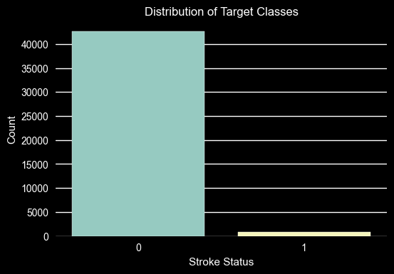

```python
# This plot tell's about, how the distribution of target class is spreaded.
# we can see that the target classes are highly imbalanced with 0->42617, 1->783, so we need to balance these target classes which we will see in the later part.
# countplot() helps us to visualize the count the classes.

plt.figure(figsize = (6,4), dpi = 100)
sns.countplot(dodge['stroke'])
plt.xlabel('Stroke Status')
plt.ylabel('Count')
plt.title('Distribution of Target Classes')
plt.show()
```

### **Exploring Independent Numerical Columns.**

1. Cleaning
2. Treating Missing values
3. Anamoly Detection and Reduction

```python
numerical = ['age', 'hypertension', 'heart_disease', 'avg_glucose_level', 'bmi']
#dodge[numerical[0]]
```

#### Treating missing values present in the column dodge['bmi'], no other numerical columns has missing values.

```python
dodge['bmi'].isnull().sum()
```

```
1462
```

```python
dodge['bmi'] = dodge['bmi'].fillna(dodge['bmi'].mean())
```

```python
dodge['bmi'].isnull().sum()
```

```
0
```

#### Exploring each numerical column using describe()

```python
for i in numerical:
  print(dodge[i].describe())
```

```
count    43400.000000
mean        42.217894
std         22.519649
min          0.080000
25%         24.000000
50%         44.000000
75%         60.000000
max         82.000000
Name: age, dtype: float64
count    43400.000000
mean         0.093571
std          0.291235
min          0.000000
25%          0.000000
50%          0.000000
75%          0.000000
max          1.000000
Name: hypertension, dtype: float64
count    43400.000000
mean         0.047512
std          0.212733
min          0.000000
25%          0.000000
50%          0.000000
75%          0.000000
max          1.000000
Name: heart_disease, dtype: float64
count    43400.000000
mean       104.482750
std         43.111751
min         55.000000
25%         77.540000
50%         91.580000
75%        112.070000
max        291.050000
Name: avg_glucose_level, dtype: float64
count    43400.000000
mean        28.605038
std          7.638023
min         10.100000
25%         23.400000
50%         28.100000
75%         32.600000
max         97.600000
Name: bmi, dtype: float64
```

### **Anamoly Detection and Reduction in Numericals.**

#### 1. age

```python
dodge['age'].describe()
```

```
count    43400.000000
mean        42.217894
std         22.519649
min          0.080000
25%         24.000000
50%         44.000000
75%         60.000000
max         82.000000
Name: age, dtype: float64
```

```python
dodge['age'].value_counts()
```

```
51.00    738
52.00    721
53.00    701
78.00    698
50.00    694
        ...
0.48      37
0.40      35
1.00      34
0.16      26
0.08      17
Name: age, Length: 104, dtype: int64
```

Function to check the Anamolies in the column using upper_limit and lower_limit.

1. If the upper_limit > max(df['col']), then we replace the upper_limit with the max value.
2. Similarly, if the lower_limit < min(df['col']), we replace the lower_limit with the min value.

```python
anamolies = []
def outliers(data):
  random_state_mean = np.mean(data)
  random_state_std = np.std(data)
  anamoly = random_state_std * 3

  upper_limit = random_state_mean + anamoly
  lower_limit = random_state_mean - anamoly
  lp_lower_limit = 1.00
  up_upper_limit = max(dodge['age'])
  print(upper_limit)
  print(lower_limit)

  print(lp_lower_limit)
  print(up_upper_limit)

  for i in data:
      if i < lp_lower_limit or i > up_upper_limit:
        anamolies.append(i)
```

```python
outliers(dodge['age'])
print(len(anamolies))
```

```
109.7760617173718
-25.340273698938617
1.0
82.0
496
```

```python
dodge.shape
```

```
(43400, 12)
```

Here all the values below 1 are termed as outliers, although in rarest of cases Intrauterine stroke occur to unborn childre in the womb.

But in this project we drop those values, but in future we can even work on these values.

```python
dodge[dodge['age'] < 1.00]
```

|  | id | gender | age | hypertension | heart_disease | ever_married | work_type | Residence_type | avg_glucose_level | bmi | smoking_status | stroke |
| --- | --- | --- | --- | --- | --- | --- | --- | --- | --- | --- | --- | --- |
| 116 | 7559 | Female | 0.64 | 0 | 0 | No | children | Urban | 83.82 | 24.9 | NaN | 0 |
| 129 | 22706 | Female | 0.88 | 0 | 0 | No | children | Rural | 88.11 | 15.5 | NaN | 0 |
| 323 | 61511 | Female | 0.32 | 0 | 0 | No | children | Rural | 73.71 | 16.2 | NaN | 0 |
| 746 | 54747 | Male | 0.88 | 0 | 0 | No | children | Rural | 157.57 | 19.2 | NaN | 0 |
| 761 | 53279 | Male | 0.24 | 0 | 0 | No | children | Rural | 118.87 | 16.3 | NaN | 0 |
| ... | ... | ... | ... | ... | ... | ... | ... | ... | ... | ... | ... | ... |
| 43031 | 2698 | Female | 0.32 | 0 | 0 | No | children | Urban | 91.86 | 17.6 | NaN | 0 |
| 43106 | 51999 | Male | 0.32 | 0 | 0 | No | children | Urban | 90.38 | 16.1 | NaN | 0 |
| 43220 | 36634 | Female | 0.08 | 0 | 0 | No | children | Rural | 125.11 | 12.1 | NaN | 0 |
| 43296 | 52578 | Male | 0.56 | 0 | 0 | No | children | Rural | 78.07 | 21.9 | NaN | 0 |
| 43330 | 18634 | Female | 0.72 | 0 | 0 | No | children | Urban | 87.74 | 16.6 | NaN | 0 |

496 rows × 12 columns

```python
dodge[dodge['age'] < 1.00].index
```

```
Int64Index([  116,   129,   323,   746,   761,   861,   975,  1087,  1375,
             1389,
            ...
            42637, 42862, 42880, 42881, 42982, 43031, 43106, 43220, 43296,
            43330],
           dtype='int64', length=496)
```

```python
chevy = dodge.drop(index = dodge[dodge['age'] < 1.00].index, axis = 0, inplace=True)
```

```python
dodge.drop(index = dodge[(dodge.age > 1.0) & (dodge.age < 2.0)].index, axis = 0, inplace = True)
```

```python
dodge.shape
```

```
(42309, 12)
```

#### 2. avg_glucose_level(Average Glucose Level)

```python
anamolies = []
def outliers(data):
  random_state_mean = np.mean(data)
  random_state_std = np.std(data)
  anamoly = random_state_std * 3

  upper_limit = random_state_mean + anamoly
  lower_limit = random_state_mean - anamoly
  ll_p = min(dodge['avg_glucose_level'])

  print(upper_limit)
  print(lower_limit)
  print(ll_p)
  for i in data:
    if i < ll_p or i > upper_limit:
      anamolies.append(i)
```

```python
outliers(dodge['avg_glucose_level'])
print(len(anamolies))
```

```
235.13454455171652
-25.55617162869774
55.0
575
```

```python
dodge['avg_glucose_level'].describe()
```

```
count    42309.000000
mean       104.789186
std         43.448966
min         55.000000
25%         77.570000
50%         91.650000
75%        112.260000
max        291.050000
Name: avg_glucose_level, dtype: float64
```

```python
dodge[dodge['avg_glucose_level'] > 234.40827023316058 ]
```

|  | id | gender | age | hypertension | heart_disease | ever_married | work_type | Residence_type | avg_glucose_level | bmi | smoking_status | stroke |
| --- | --- | --- | --- | --- | --- | --- | --- | --- | --- | --- | --- | --- |
| 7 | 41413 | Female | 75.0 | 0 | 1 | Yes | Self-employed | Rural | 243.53 | 27.000000 | never smoked | 0 |
| 54 | 18518 | Male | 66.0 | 0 | 0 | Yes | Private | Rural | 242.30 | 35.300000 | smokes | 0 |
| 77 | 4480 | Male | 76.0 | 0 | 0 | Yes | Private | Rural | 234.58 | 34.300000 | formerly smoked | 0 |
| 78 | 2982 | Female | 57.0 | 1 | 0 | Yes | Private | Rural | 235.85 | 40.100000 | never smoked | 0 |
| 83 | 59368 | Female | 78.0 | 0 | 0 | Yes | Private | Urban | 243.50 | 26.100000 | never smoked | 0 |
| ... | ... | ... | ... | ... | ... | ... | ... | ... | ... | ... | ... | ... |
| 43228 | 27207 | Male | 41.0 | 1 | 0 | Yes | Private | Rural | 271.01 | 25.800000 | NaN | 0 |
| 43279 | 49997 | Male | 67.0 | 0 | 0 | Yes | Self-employed | Rural | 242.61 | 47.000000 | NaN | 0 |
| 43283 | 29575 | Female | 30.0 | 0 | 0 | No | Self-employed | Urban | 258.24 | 28.605038 | never smoked | 0 |
| 43287 | 22198 | Male | 66.0 | 0 | 0 | Yes | Private | Rural | 238.23 | 33.300000 | formerly smoked | 0 |
| 43358 | 40203 | Male | 78.0 | 0 | 0 | Yes | Self-employed | Rural | 248.93 | 21.600000 | formerly smoked | 0 |

617 rows × 12 columns

```python
dodge[dodge['avg_glucose_level'] > 234.40827023316058].index
```

```
Int64Index([    7,    54,    77,    78,    83,    96,   139,   310,   322,
              469,
            ...
            43140, 43144, 43155, 43175, 43188, 43228, 43279, 43283, 43287,
            43358],
           dtype='int64', length=617)
```

```python
dodge.drop(index = dodge[dodge['avg_glucose_level'] > 234.40827023316058].index, axis = 0, inplace = True)
```

```python
dodge.shape
```

```
(41692, 12)
```

#### 3. bmi(Body Mass Index)

```python
anamolies = []
def outliers(data):
  random_state_mean = np.mean(data)
  random_state_std = np.std(data)
  anamoly = random_state_std * 3

  upper_limit = random_state_mean + anamoly
  lower_limit = random_state_mean - anamoly
  lll_p = min(dodge['bmi'])

  print(upper_limit)
  print(lower_limit)
  print(lll_p)
  for i in data:
    if i < lll_p or i > upper_limit:
      anamolies.append(i)
```

```python
outliers(dodge['bmi'])
print(len(anamolies))
```

```
51.34051370653113
6.268167446955189
10.1
431
```

```python
dodge['bmi'].describe()
```

```
count    41692.000000
mean        28.804341
std          7.512148
min         10.100000
25%         23.700000
50%         28.200000
75%         32.700000
max         97.600000
Name: bmi, dtype: float64
```

```python
dodge[dodge['bmi'] > 51.35486554902225]
```

|  | id | gender | age | hypertension | heart_disease | ever_married | work_type | Residence_type | avg_glucose_level | bmi | smoking_status | stroke |
| --- | --- | --- | --- | --- | --- | --- | --- | --- | --- | --- | --- | --- |
| 9 | 28674 | Female | 74.0 | 1 | 0 | Yes | Self-employed | Urban | 205.84 | 54.6 | never smoked | 0 |
| 21 | 72911 | Female | 57.0 | 1 | 0 | Yes | Private | Rural | 129.54 | 60.9 | smokes | 0 |
| 86 | 1703 | Female | 52.0 | 0 | 0 | Yes | Private | Urban | 82.24 | 54.7 | formerly smoked | 0 |
| 111 | 66333 | Male | 52.0 | 0 | 0 | Yes | Self-employed | Urban | 78.40 | 64.8 | never smoked | 0 |
| 184 | 53144 | Female | 52.0 | 0 | 1 | Yes | Private | Urban | 72.79 | 54.7 | never smoked | 0 |
| ... | ... | ... | ... | ... | ... | ... | ... | ... | ... | ... | ... | ... |
| 43025 | 14846 | Male | 50.0 | 1 | 0 | Yes | Govt_job | Rural | 75.29 | 52.0 | never smoked | 0 |
| 43087 | 70198 | Male | 78.0 | 1 | 0 | Yes | Private | Rural | 135.73 | 89.0 | never smoked | 0 |
| 43239 | 36167 | Male | 21.0 | 0 | 0 | No | Private | Urban | 83.78 | 54.9 | never smoked | 0 |
| 43355 | 57237 | Female | 46.0 | 0 | 0 | Yes | Private | Rural | 99.81 | 53.2 | NaN | 0 |
| 43396 | 5450 | Female | 56.0 | 0 | 0 | Yes | Govt_job | Urban | 213.61 | 55.4 | formerly smoked | 0 |

431 rows × 12 columns

```python
dodge[dodge['bmi'] > 51.35486554902225].index
```

```
Int64Index([    9,    21,    86,   111,   184,   220,   297,   302,   396,
              422,
            ...
            42560, 42589, 42604, 42831, 42977, 43025, 43087, 43239, 43355,
            43396],
           dtype='int64', length=431)
```

```python
dodge.drop(index = dodge[dodge['bmi'] > 51.35486554902225].index, axis = 0, inplace = True)
```

```python
dodge.shape
```

```
(41261, 12)
```

### **Exploring Independent Categorical(Object/String) Columns.**

1. Cleaning
2. Treating Missing values

```python
dodge.isnull().sum()
```

```
id                       0
gender                   0
age                      0
hypertension             0
heart_disease            0
ever_married             0
work_type                0
Residence_type           0
avg_glucose_level        0
bmi                      0
smoking_status       12015
stroke                   0
dtype: int64
```

```python
categorical = ['gender', 'ever_married', 'work_type', 'Residence_type', 'smoking_status']
```

```python
for i in categorical:
  print(dodge[i].describe())
```

```
count      41261
unique         3
top       Female
freq       24498
Name: gender, dtype: object
count     41261
unique        2
top         Yes
freq      27051
Name: ever_married, dtype: object
count       41261
unique          5
top       Private
freq        24195
Name: work_type, dtype: object
count     41261
unique        2
top       Urban
freq      20664
Name: Residence_type, dtype: object
count            29246
unique               3
top       never smoked
freq             15655
Name: smoking_status, dtype: object
```

```python
dodge.describe(include = 'object')
```

|  | gender | ever_married | work_type | Residence_type | smoking_status |
| --- | --- | --- | --- | --- | --- |
| count | 41261 | 41261 | 41261 | 41261 | 29246 |
| unique | 3 | 2 | 5 | 2 | 3 |
| top | Female | Yes | Private | Urban | never smoked |
| freq | 24498 | 27051 | 24195 | 20664 | 15655 |

```python
dodge['smoking_status'].value_counts()
```

```
never smoked       15655
formerly smoked     7222
smokes              6369
Name: smoking_status, dtype: int64
```

```python
dodge.describe(include = 'all')
```

|  | id | gender | age | hypertension | heart_disease | ever_married | work_type | Residence_type | avg_glucose_level | bmi | smoking_status | stroke |
| --- | --- | --- | --- | --- | --- | --- | --- | --- | --- | --- | --- | --- |
| count | 41261.000000 | 41261 | 41261.000000 | 41261.000000 | 41261.000000 | 41261 | 41261 | 41261 | 41261.000000 | 41261.000000 | 29246 | 41261.000000 |
| unique | NaN | 3 | NaN | NaN | NaN | 2 | 5 | 2 | NaN | NaN | 3 | NaN |
| top | NaN | Female | NaN | NaN | NaN | Yes | Private | Urban | NaN | NaN | never smoked | NaN |
| freq | NaN | 24498 | NaN | NaN | NaN | 27051 | 24195 | 20664 | NaN | NaN | 15655 | NaN |
| mean | 36315.893992 | NaN | 42.998134 | 0.092533 | 0.046945 | NaN | NaN | NaN | 102.504529 | 28.509461 | NaN | 0.018032 |
| std | 21080.388177 | NaN | 21.848829 | 0.289780 | 0.211524 | NaN | NaN | NaN | 39.968402 | 6.942450 | NaN | 0.133067 |
| min | 1.000000 | NaN | 1.000000 | 0.000000 | 0.000000 | NaN | NaN | NaN | 55.000000 | 10.100000 | NaN | 0.000000 |
| 25% | 18007.000000 | NaN | 25.000000 | 0.000000 | 0.000000 | NaN | NaN | NaN | 77.370000 | 23.700000 | NaN | 0.000000 |
| 50% | 36315.000000 | NaN | 44.000000 | 0.000000 | 0.000000 | NaN | NaN | NaN | 91.170000 | 28.100000 | NaN | 0.000000 |
| 75% | 54539.000000 | NaN | 60.000000 | 0.000000 | 0.000000 | NaN | NaN | NaN | 110.770000 | 32.500000 | NaN | 0.000000 |
| max | 72943.000000 | NaN | 82.000000 | 1.000000 | 1.000000 | NaN | NaN | NaN | 234.380000 | 51.300000 | NaN | 1.000000 |

#### Treating Missing values in Object columns using,

1. mean/median/mode
2. Based on frequency Distribution.

```python
dodge['smoking_status'].mode()
```

```
0    never smoked
dtype: object
```

```python
dodge['smoking_status'].fillna('never smoked',inplace = True)
```

```python
dodge['smoking_status'].isnull().sum()
```

```
0
```

```python
dodge.info()
```

```
<class 'pandas.core.frame.DataFrame'>
Int64Index: 41261 entries, 0 to 43399
Data columns (total 12 columns):
 #   Column             Non-Null Count  Dtype
---  ------             --------------  -----
 0   id                 41261 non-null  int64
 1   gender             41261 non-null  object
 2   age                41261 non-null  float64
 3   hypertension       41261 non-null  int64
 4   heart_disease      41261 non-null  int64
 5   ever_married       41261 non-null  object
 6   work_type          41261 non-null  object
 7   Residence_type     41261 non-null  object
 8   avg_glucose_level  41261 non-null  float64
 9   bmi                41261 non-null  float64
 10  smoking_status     41261 non-null  object
 11  stroke             41261 non-null  int64
dtypes: float64(3), int64(4), object(5)
memory usage: 4.1+ MB
```

```python
dodge.head()
```

|  | id | gender | age | hypertension | heart_disease | ever_married | work_type | Residence_type | avg_glucose_level | bmi | smoking_status | stroke |
| --- | --- | --- | --- | --- | --- | --- | --- | --- | --- | --- | --- | --- |
| 0 | 30669 | Male | 3.0 | 0 | 0 | No | children | Rural | 95.12 | 18.0 | never smoked | 0 |
| 1 | 30468 | Male | 58.0 | 1 | 0 | Yes | Private | Urban | 87.96 | 39.2 | never smoked | 0 |
| 2 | 16523 | Female | 8.0 | 0 | 0 | No | Private | Urban | 110.89 | 17.6 | never smoked | 0 |
| 3 | 56543 | Female | 70.0 | 0 | 0 | Yes | Private | Rural | 69.04 | 35.9 | formerly smoked | 0 |
| 4 | 46136 | Male | 14.0 | 0 | 0 | No | Never_worked | Rural | 161.28 | 19.1 | never smoked | 0 |

### **Exploratory Data Analysis.**

Exploratory Data Analysis helps us the understand the insights and extract the patterns from the dataset, which might be helpful to explain about the problem statement given to our clients. This can also be done by using traditional python code, But Visualizing the data looks more eye catching than looking at some numbers and letters. so, hence we are going to use various plots and graphs to visualize, which comes from the libraries such as, seaborn and matplotlib.pyplot.

1. bar
2. countplot
3. piechart
4. hist
5. box
6. scatterplot
7. pairplot

Apart from this we have also used and auto visualization tool, "autoviz"

```python
dodge.isnull().sum()
```

```
id                   0
gender               0
age                  0
hypertension         0
heart_disease        0
ever_married         0
work_type            0
Residence_type       0
avg_glucose_level    0
bmi                  0
smoking_status       0
stroke               0
dtype: int64
```

```python
dodge.drop(columns = 'id', inplace=True)
```

```python
dodge.head()
```

|  | gender | age | hypertension | heart_disease | ever_married | work_type | Residence_type | avg_glucose_level | bmi | smoking_status | stroke |
| --- | --- | --- | --- | --- | --- | --- | --- | --- | --- | --- | --- |
| 0 | Male | 3.0 | 0 | 0 | No | children | Rural | 95.12 | 18.0 | never smoked | 0 |
| 1 | Male | 58.0 | 1 | 0 | Yes | Private | Urban | 87.96 | 39.2 | never smoked | 0 |
| 2 | Female | 8.0 | 0 | 0 | No | Private | Urban | 110.89 | 17.6 | never smoked | 0 |
| 3 | Female | 70.0 | 0 | 0 | Yes | Private | Rural | 69.04 | 35.9 | formerly smoked | 0 |
| 4 | Male | 14.0 | 0 | 0 | No | Never_worked | Rural | 161.28 | 19.1 | never smoked | 0 |

-> pd.crosstab() function is a very useful and most advanced fuction in the python dataframe, it helps us to compare 2 variables, due to which we can plot the distribution of thsoe variables.

#### 1. Bar plot for crosstab distribution between gender and stroke.

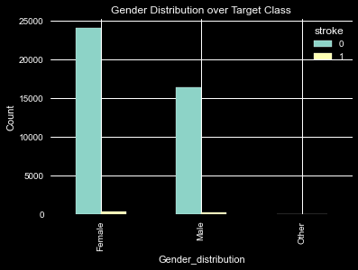

```python
plt.figure(figsize = (8,6))
x = pd.crosstab(dodge['gender'], dodge['stroke'])
x.plot(kind = 'bar')
#x.div(x.sum(1).astype(float), axis = 0).plot(kind='bar', stacked = False)
plt.xlabel('Gender_distribution')
plt.ylabel('Count')
plt.title('Gender Distribution over Target Class')
plt.show()
```

#### 2. Pie Chart for distribution of gender.

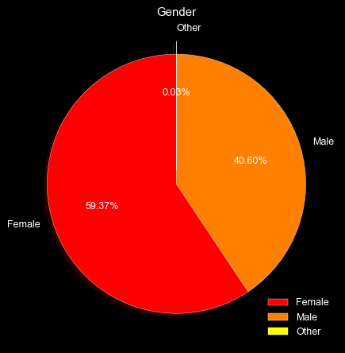

```python
# PIE CHART for dodge['gender'] column.

plt.figure(figsize = (8,6), dpi = 90)
labels = dodge['gender'].value_counts().index
sizes = dodge['gender'].value_counts()
explode = [0,0,0.1]
colors = plt.cm.autumn(np.linspace(0,1,3))
plt.pie(sizes, colors=colors, labels=labels, explode=explode, shadow =True, startangle=90, autopct = '%.2f%%' )
plt.title('Gender',fontsize=12)
plt.legend()
plt.show()
```

#### 3. Bar chart for gender-hypertentsion distribution.

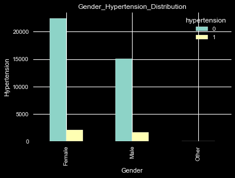

```python
plt.figure(figsize = (8,6), dpi = 90)
x = pd.crosstab(dodge['gender'],dodge['hypertension'])
x.plot(kind = 'bar')
plt.xlabel('Gender')
plt.ylabel('Hypertension')
plt.title("Gender_Hypertension_Distribution")
plt.show()
```

#### 4. Bar Chart for age-hypertension distribution

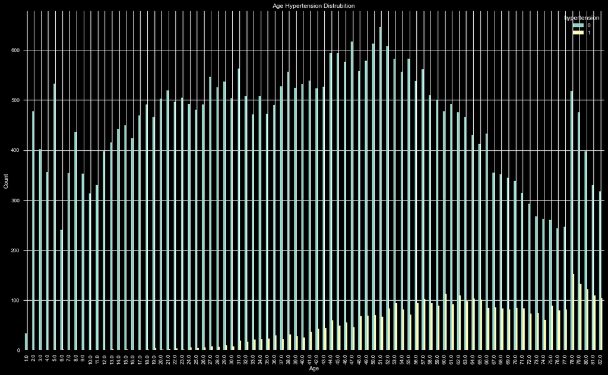

```python
plt.rcParams['figure.figsize'] = (20,12)
x = pd.crosstab(dodge['age'], dodge['hypertension'])
x.plot(kind = 'bar')
plt.xlabel('Age')
plt.ylabel('Count')
plt.title("Age Hypertension Distrubition")
plt.show()
```

#### 5. Bar Chart for gender-heart_disease distribution

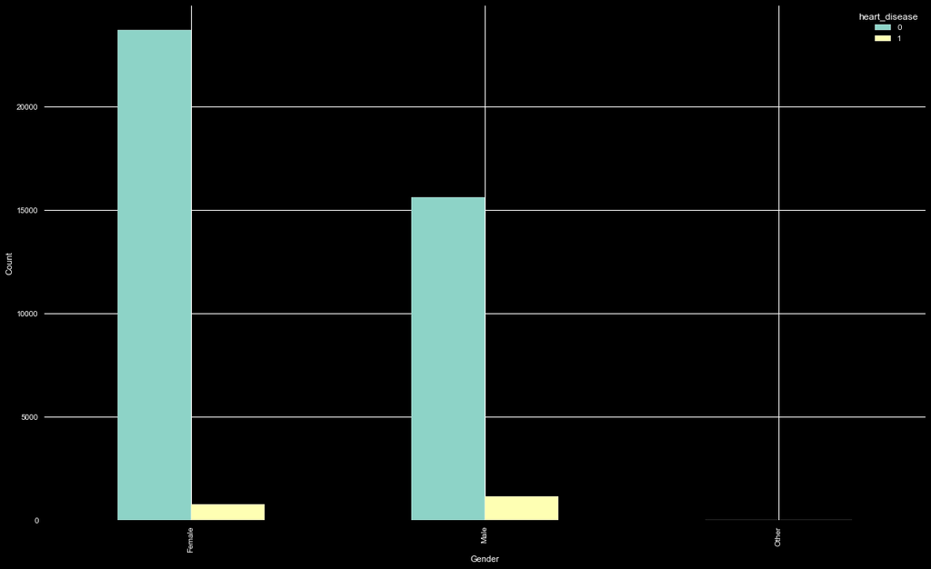

```python
plt.figure(figsize=(12,10))
ab = pd.crosstab(dodge['gender'], dodge['heart_disease'])
ab.plot(kind = 'bar')
plt.xlabel('Gender')
plt.ylabel('Count')
plt.show()
```

#### 6. age-stroke distribution

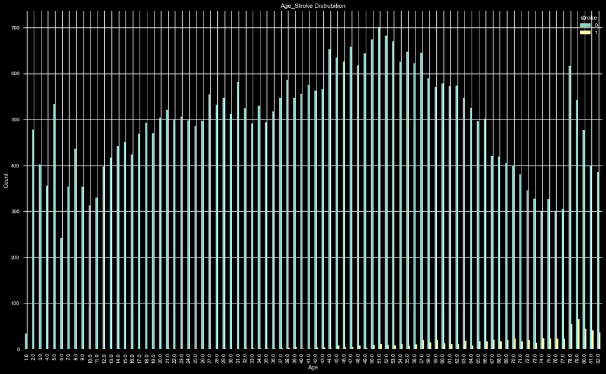

```python
plt.rcParams['figure.figsize'] = (20,12)
x = pd.crosstab(dodge['age'], dodge['stroke'])
x.plot(kind = 'bar')
plt.xlabel('Age')
plt.ylabel('Count')
plt.title("Age_Stroke Distrubition")
plt.show()
```

#### 7. age-heart_disease distribution.

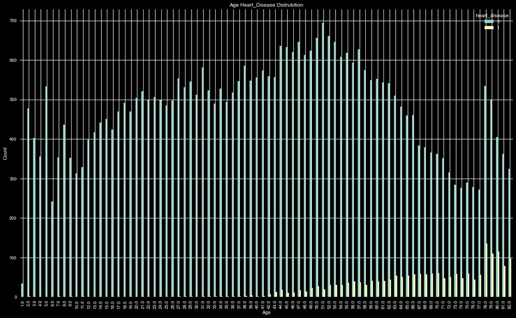

```python
plt.rcParams['figure.figsize'] = (20,12)
#plt.figure(figsize =(13,6))
x = pd.crosstab(dodge['age'], dodge['heart_disease'])
x.plot(kind = 'bar')
plt.xlabel('Age')
plt.ylabel('Count')
plt.title("Age Heart_Disease Distrubition")
plt.show()
```

#### 8. Distribution of people getting stroke with respect to whether they are married or not.

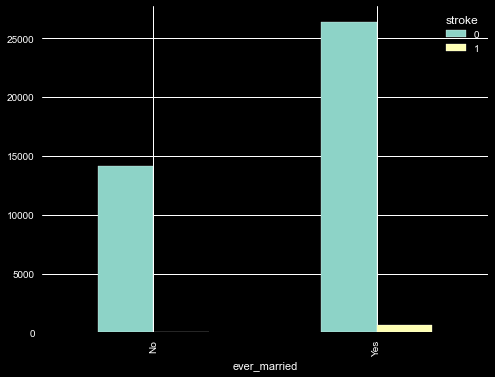

```python
plt.rcParams['figure.figsize'] = (8,6)
h = pd.crosstab(dodge['ever_married'], dodge['stroke'])
h.plot(kind ='bar')
plt.show()
```

#### 9. Scatterplot for avg_glucose level and bmi with hue as stroke, hue is an additional parameter which seperates the classes using different colors.

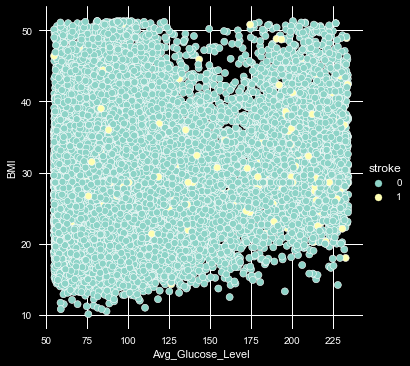

```python
plt.rcParams['figure.figsize'] = (20,12)
sns.relplot(dodge['avg_glucose_level'], dodge['bmi'], hue = dodge['stroke'], kind = 'scatter')
plt.xlabel('Avg_Glucose_Level')
plt.ylabel('BMI')
plt.show()
```

#### 10. Countplot() for checking distribution of work_type.

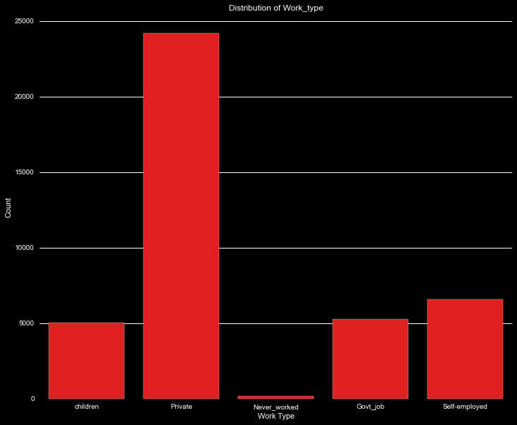

```python
plt.figure(figsize = (12,10))
sns.countplot(dodge['work_type'], color ='red')
plt.xlabel("Work Type")
plt.ylabel('Count')
plt.title("Distribution of Work_type")
plt.show()
```

#### 11. Distribution of work_type with respect to stroke occurence.

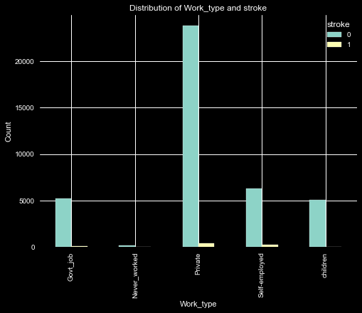

```python
plt.rcParams['figure.figsize'] = (8,6)
h = pd.crosstab(dodge['work_type'], dodge['stroke'])
h.plot(kind ='bar')
plt.xlabel("Work_type")
plt.ylabel("Count")
plt.title("Distribution of Work_type and stroke")
plt.show()
```

#### autoviz -> An AutoVisualization tool, which helps to visualize the features in the dataset more in depth.

```
Shape of your Data Set: (43400, 12)
############## C L A S S I F Y I N G  V A R I A B L E S  ####################
Classifying variables in data set...
Data Set Shape: 43400 rows, 12 cols
Data Set columns info:
* id: 0 nulls, 43400 unique vals, most common: {2047: 1, 42270: 1}
* gender: 0 nulls, 3 unique vals, most common: {'Female': 25665, 'Male': 17724}
* age: 0 nulls, 104 unique vals, most common: {51.0: 738, 52.0: 721}
* hypertension: 0 nulls, 2 unique vals, most common: {0: 39339, 1: 4061}
* heart_disease: 0 nulls, 2 unique vals, most common: {0: 41338, 1: 2062}
* ever_married: 0 nulls, 2 unique vals, most common: {'Yes': 27938, 'No': 15462}
* work_type: 0 nulls, 5 unique vals, most common: {'Private': 24834, 'Self-employed': 6793}
* Residence_type: 0 nulls, 2 unique vals, most common: {'Urban': 21756, 'Rural': 21644}
* avg_glucose_level: 0 nulls, 12543 unique vals, most common: {82.71: 19, 87.07: 18}
* bmi: 1462 nulls, 555 unique vals, most common: {27.7: 271, 27.6: 267}
* smoking_status: 13292 nulls, 3 unique vals, most common: {'never smoked': 16053, 'formerly smoked': 7493}
* stroke: 0 nulls, 2 unique vals, most common: {0: 42617, 1: 783}
--------------------------------------------------------------------
    Numeric Columns: ['age', 'avg_glucose_level', 'bmi']
    Integer-Categorical Columns: []
    String-Categorical Columns: ['gender', 'work_type', 'smoking_status']
    Factor-Categorical Columns: []
    String-Boolean Columns: ['ever_married', 'Residence_type']
    Numeric-Boolean Columns: ['hypertension', 'heart_disease', 'stroke']
    Discrete String Columns: []
    NLP text Columns: []
    Date Time Columns: []
    ID Columns: ['id']
    Columns that will not be considered in modeling: []
    12 Predictors classified...
        This does not include the Target column(s)
        1 variables removed since they were ID or low-information variables
    List of variables removed: ['id']
Number of All Scatter Plots = 6
Time to run AutoViz (in seconds) = 9.392
```

|  | gender | age | hypertension | heart_disease | ever_married | work_type | Residence_type | avg_glucose_level | bmi | smoking_status | stroke |
| --- | --- | --- | --- | --- | --- | --- | --- | --- | --- | --- | --- |
| 0 | Male | 3.0 | 0 | 0 | No | children | Rural | 95.12 | 18.0 | NaN | 0 |
| 1 | Male | 58.0 | 1 | 0 | Yes | Private | Urban | 87.96 | 39.2 | never smoked | 0 |
| 2 | Female | 8.0 | 0 | 0 | No | Private | Urban | 110.89 | 17.6 | NaN | 0 |
| 3 | Female | 70.0 | 0 | 0 | Yes | Private | Rural | 69.04 | 35.9 | formerly smoked | 0 |
| 4 | Male | 14.0 | 0 | 0 | No | Never_worked | Rural | 161.28 | 19.1 | NaN | 0 |
| ... | ... | ... | ... | ... | ... | ... | ... | ... | ... | ... | ... |
| 43395 | Female | 10.0 | 0 | 0 | No | children | Urban | 58.64 | 20.4 | never smoked | 0 |
| 43396 | Female | 56.0 | 0 | 0 | Yes | Govt_job | Urban | 213.61 | 55.4 | formerly smoked | 0 |
| 43397 | Female | 82.0 | 1 | 0 | Yes | Private | Urban | 91.94 | 28.9 | formerly smoked | 0 |
| 43398 | Male | 40.0 | 0 | 0 | Yes | Private | Urban | 99.16 | 33.2 | never smoked | 0 |
| 43399 | Female | 82.0 | 0 | 0 | Yes | Private | Urban | 79.48 | 20.6 | never smoked | 0 |

43400 rows × 11 columns

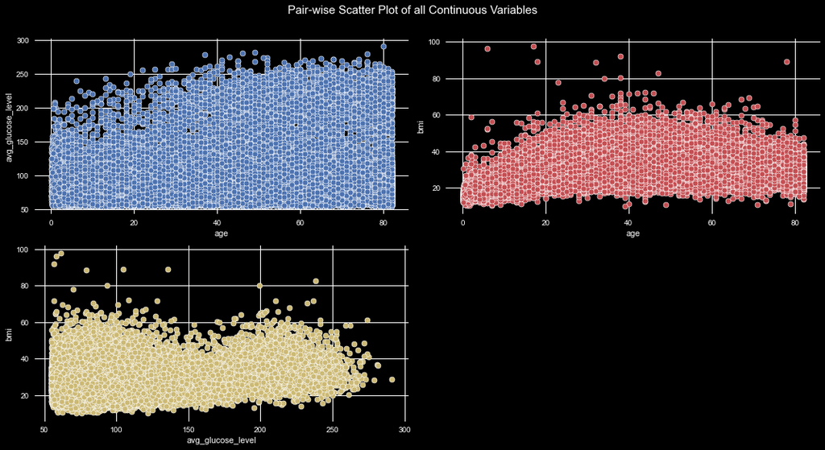

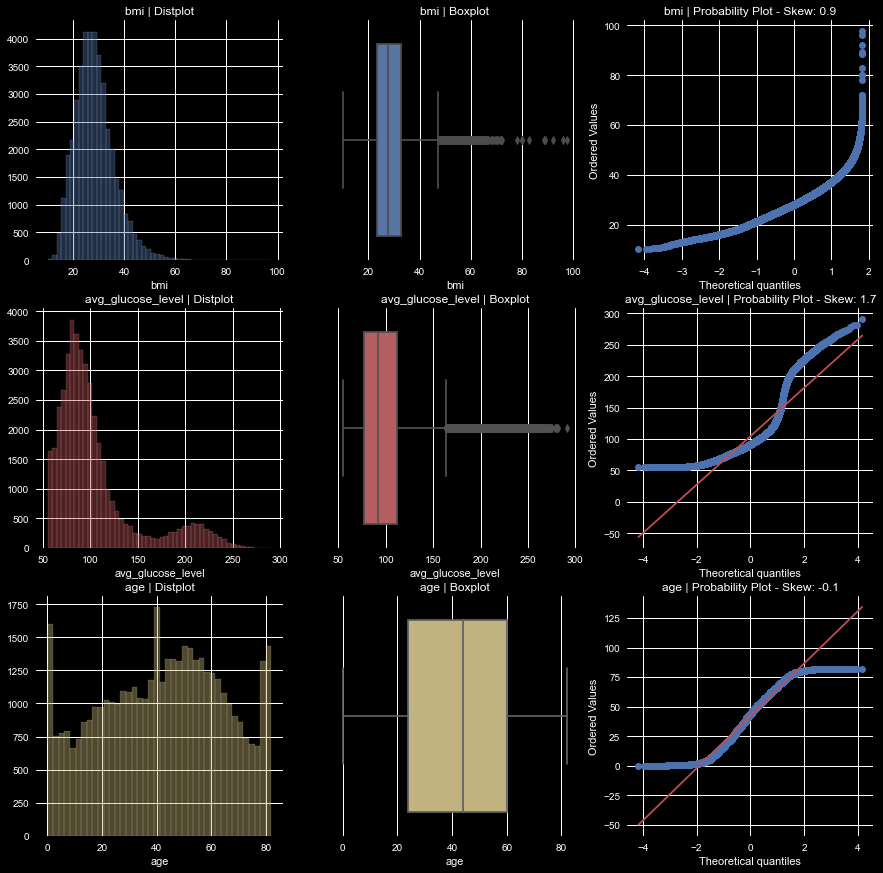

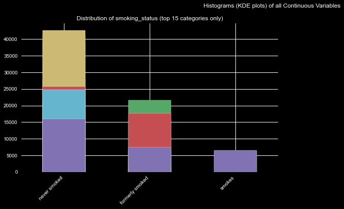

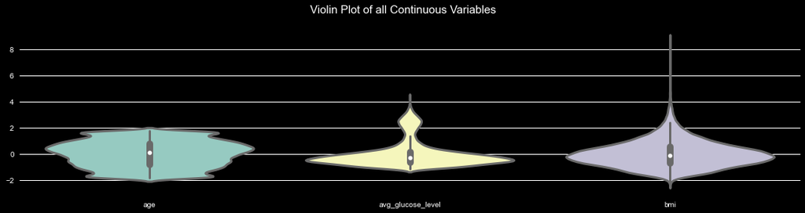

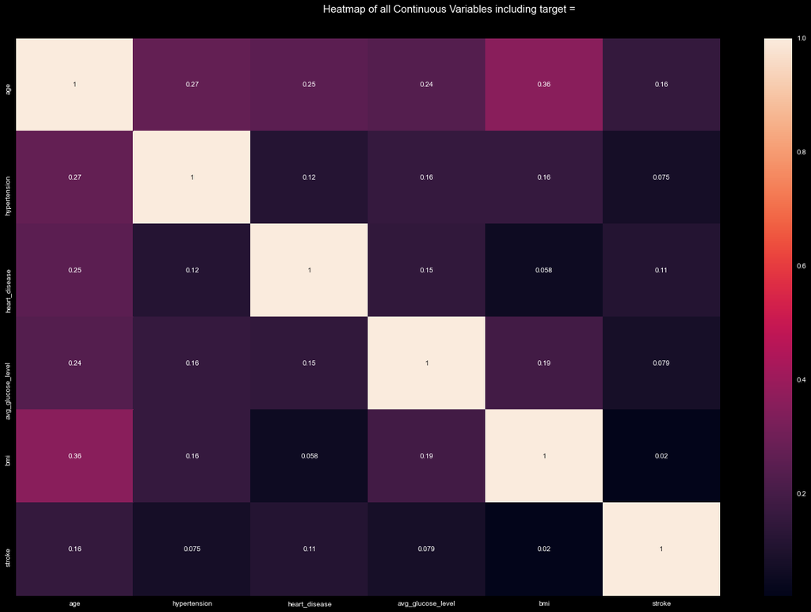

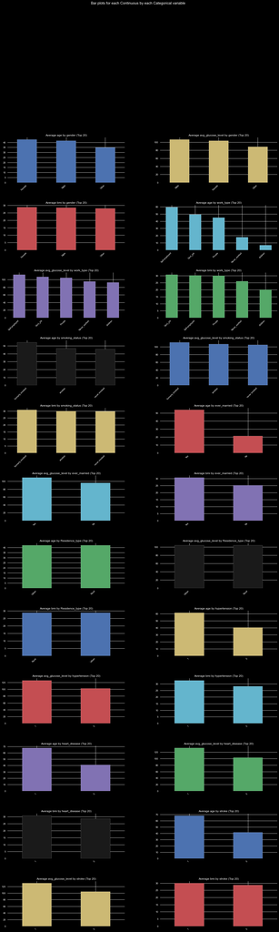

```python
AV = AutoViz_Class()
autovis = AV.AutoViz(filename = 'train_strokes.csv', sep=',', depVar='', dfte=None, header=0, verbose=2,
                            lowess=False,chart_format='svg',max_rows_analyzed=150000,max_cols_analyzed=30)
autovis
```

### **Exploring data using Traditional python code, with the help of interactive widgets.**

```python
abg = dodge[['hypertension', 'heart_disease']].groupby(['hypertension']).count().style.background_gradient(cmap = 'viridis')
```

Sum of Heart Disease values with respect to hypertension, This can be easily eaxplained by crosstab()

```python
abg
```

| hypertension | heart_disease |
| --- | --- |
| 0 | 37443 |
| 1 | 3818 |

```python
dre = pd.crosstab(dodge['hypertension'], dodge['heart_disease'])
dre
```

| heart_disease hypertension | 0 | 1 |
| --- | --- | --- |
| 0 | 35984 | 1459 |
| 1 | 3340 | 478 |

#### @interact:

The interact function (ipywidgets.interact) automatically creates user interface (UI) controls for exploring code and data interactively.

The function gets called each time the slider is moved.

```python
@interact
def abc(x = 50):
  y = dodge[dodge['avg_glucose_level'] > x]
  return y['stroke'].value_counts()
abc()
```

```
0    40517
1      744
Name: stroke, dtype: int64
```

```python
@interact
def hyp_heart(x=0, y=0):
  g = dodge[(dodge['hypertension'] == x) & (dodge['heart_disease'] == y)]
  return g['stroke'].value_counts()
hyp_heart()
```

```
0    35541
1      443
Name: stroke, dtype: int64
```

```python
@interact
def hy_he_eve(x=0,y=0,z='No'):
  j = dodge[(dodge['hypertension'] == x) & (dodge['heart_disease'] == y) & (dodge['ever_married'] == z)]
  return j['stroke'].value_counts(), j['smoking_status'].value_counts()
hy_he_eve()
```

```
(0    13690
 1       44
 Name: stroke, dtype: int64,
 never smoked       11124
 smokes              1437
 formerly smoked     1173
 Name: smoking_status, dtype: int64)
```

### **Feature Transformation.**

Feature Transformation is the technique of transforming the variable into other form like Strings -> Numeric, splitting the Date Column in to pieces etc.

Types of encoding.

#### 1. Nominal Encoding.

- one hot encoding -> Creating Dummy variables.
- one hot encoding with multi categories(more than 20 categories)
- mean encoding

#### 2. Ordinal Encoding.

- Label Encoder
- target_guided_encoding

-> For the columns with less than 5 categories we can manually perform encoding, usinf map().

-> For Columns with more than 20 Categories we can perform one hot encoding with multi categories, where we tend to select the top categories based on their value_counts().

```python
dodge.head()
```

|  | gender | age | hypertension | heart_disease | ever_married | work_type | Residence_type | avg_glucose_level | bmi | smoking_status | stroke |
| --- | --- | --- | --- | --- | --- | --- | --- | --- | --- | --- | --- |
| 0 | Male | 3.0 | 0 | 0 | No | children | Rural | 95.12 | 18.0 | never smoked | 0 |
| 1 | Male | 58.0 | 1 | 0 | Yes | Private | Urban | 87.96 | 39.2 | never smoked | 0 |
| 2 | Female | 8.0 | 0 | 0 | No | Private | Urban | 110.89 | 17.6 | never smoked | 0 |
| 3 | Female | 70.0 | 0 | 0 | Yes | Private | Rural | 69.04 | 35.9 | formerly smoked | 0 |
| 4 | Male | 14.0 | 0 | 0 | No | Never_worked | Rural | 161.28 | 19.1 | never smoked | 0 |

```python
dodge['smoking_status'].unique()
```

```
array(['never smoked', 'formerly smoked', 'smokes'], dtype=object)
```

```python
mapping = {'Male':2, 'Female':1, 'Other':0}
mapping1 = {'No':0, 'Yes':1}
mapping2 = {'never smoked':0, 'formerly smoked':1, 'smokes':2}
```

```python
dodge['gender'] = dodge['gender'].map(mapping)
```

```python
dodge['ever_married'] = dodge['ever_married'].map(mapping1)
```

```python
dodge['smoking_status'] = dodge['smoking_status'].map(mapping2)
```

```python
dodge[['gender', 'smoking_status', 'ever_married']].head()
```

|  | gender | smoking_status | ever_married |
| --- | --- | --- | --- |
| 0 | 2 | 0 | 0 |
| 1 | 2 | 0 | 1 |
| 2 | 1 | 0 | 0 |
| 3 | 1 | 1 | 1 |
| 4 | 2 | 0 | 0 |

```python
dodge['work_type'].unique()
```

```
array(['children', 'Private', 'Never_worked', 'Govt_job', 'Self-employed'],
      dtype=object)
```

```python
dodge['Residence_type'].unique()
```

```
array(['Rural', 'Urban'], dtype=object)
```

```python
dodge['home_town'] = pd.get_dummies(dodge['Residence_type'], drop_first = True)
```

Creating a new dataframe with respect to work_type.

```python
f150 = pd.get_dummies(dodge['work_type'], drop_first = True)
```

Merging 2 DataFrames(dodge,f150) with the default join.

```python
camero = pd.concat([dodge,f150], axis = 1)
```

```python
camero.head()
```

|  | gender | age | hypertension | heart_disease | ever_married | work_type | Residence_type | avg_glucose_level | bmi | smoking_status | stroke | home_town | Never_worked | Private | Self-employed | children |
| --- | --- | --- | --- | --- | --- | --- | --- | --- | --- | --- | --- | --- | --- | --- | --- | --- |
| 0 | 2 | 3.0 | 0 | 0 | 0 | children | Rural | 95.12 | 18.0 | 0 | 0 | 0 | 0 | 0 | 0 | 1 |
| 1 | 2 | 58.0 | 1 | 0 | 1 | Private | Urban | 87.96 | 39.2 | 0 | 0 | 1 | 0 | 1 | 0 | 0 |
| 2 | 1 | 8.0 | 0 | 0 | 0 | Private | Urban | 110.89 | 17.6 | 0 | 0 | 1 | 0 | 1 | 0 | 0 |
| 3 | 1 | 70.0 | 0 | 0 | 1 | Private | Rural | 69.04 | 35.9 | 1 | 0 | 0 | 0 | 1 | 0 | 0 |
| 4 | 2 | 14.0 | 0 | 0 | 0 | Never_worked | Rural | 161.28 | 19.1 | 0 | 0 | 0 | 1 | 0 | 0 | 0 |

```python
camero.rename(columns = {'Never_worked':'w_t_n_w', 'Private':'w_t_p', 'Self-employed':'w_t_s_e', 'children':'w_t_c'}, inplace = True)
```

Droping the columns ['work_type', 'Residence_type'], as we have already created dummy variables for them.

```python
camero.drop(columns = ['work_type','Residence_type'], inplace = True)
```

```python
camero.head()
```

|  | gender | age | hypertension | heart_disease | ever_married | avg_glucose_level | bmi | smoking_status | stroke | home_town | w_t_n_w | w_t_p | w_t_s_e | w_t_c |
| --- | --- | --- | --- | --- | --- | --- | --- | --- | --- | --- | --- | --- | --- | --- |
| 0 | 2 | 3.0 | 0 | 0 | 0 | 95.12 | 18.0 | 0 | 0 | 0 | 0 | 0 | 0 | 1 |
| 1 | 2 | 58.0 | 1 | 0 | 1 | 87.96 | 39.2 | 0 | 0 | 1 | 0 | 1 | 0 | 0 |
| 2 | 1 | 8.0 | 0 | 0 | 0 | 110.89 | 17.6 | 0 | 0 | 1 | 0 | 1 | 0 | 0 |
| 3 | 1 | 70.0 | 0 | 0 | 1 | 69.04 | 35.9 | 1 | 0 | 0 | 0 | 1 | 0 | 0 |
| 4 | 2 | 14.0 | 0 | 0 | 0 | 161.28 | 19.1 | 0 | 0 | 0 | 1 | 0 | 0 | 0 |

```python
camero.info()
```

```
<class 'pandas.core.frame.DataFrame'>
Int64Index: 41261 entries, 0 to 43399
Data columns (total 14 columns):
 #   Column             Non-Null Count  Dtype
---  ------             --------------  -----
 0   gender             41261 non-null  int64
 1   age                41261 non-null  float64
 2   hypertension       41261 non-null  int64
 3   heart_disease      41261 non-null  int64
 4   ever_married       41261 non-null  int64
 5   avg_glucose_level  41261 non-null  float64
 6   bmi                41261 non-null  float64
 7   smoking_status     41261 non-null  int64
 8   stroke             41261 non-null  int64
 9   home_town          41261 non-null  uint8
 10  w_t_n_w            41261 non-null  uint8
 11  w_t_p              41261 non-null  uint8
 12  w_t_s_e            41261 non-null  uint8
 13  w_t_c              41261 non-null  uint8
dtypes: float64(3), int64(6), uint8(5)
memory usage: 4.6 MB
```

### **Feature Scaling**

Feature Scaling is the technique to scale down all the values in the datset to same level, so that there will be no partiality while we train the model like bmi -> 56 getting high priority than heart_disease -> 0, so in order to remove this error, feature scaling is done.

Feature Scaling Tools.

1. Standardisation (values are centered around the mean with unit standard deviation.)
2. Normalisation/min_max scaling.(values range from 0 to 1)

#### StandardScaler()

```python
se = StandardScaler()
abh = se.fit_transform(camero.drop(columns=['stroke']))
mercury = pd.DataFrame(data = abh, columns = camero.drop(columns = ['stroke']).columns)
mercury.head()
```

|  | gender | age | hypertension | heart_disease | ever_married | avg_glucose_level | bmi | smoking_status | home_town | w_t_n_w | w_t_p | w_t_s_e | w_t_c |
| --- | --- | --- | --- | --- | --- | --- | --- | --- | --- | --- | --- | --- | --- |
| 0 | 1.208899 | -1.830699 | -0.319325 | -0.22194 | -1.379732 | -0.184761 | -1.513815 | -0.647332 | -1.001625 | -0.065637 | -1.190685 | -0.435028 | 2.675967 |
| 1 | 1.208899 | 0.686629 | 3.131608 | -0.22194 | 0.724779 | -0.363905 | 1.539898 | -0.647332 | 0.998378 | -0.065637 | 0.839853 | -0.435028 | -0.373697 |
| 2 | -0.825374 | -1.601851 | -0.319325 | -0.22194 | -1.379732 | 0.209805 | -1.571433 | -0.647332 | 0.998378 | -0.065637 | 0.839853 | -0.435028 | -0.373697 |
| 3 | -0.825374 | 1.235865 | -0.319325 | -0.22194 | 0.724779 | -0.837285 | 1.064556 | 0.690823 | -1.001625 | -0.065637 | 0.839853 | -0.435028 | -0.373697 |
| 4 | 1.208899 | -1.327233 | -0.319325 | -0.22194 | -1.379732 | 1.470566 | -1.355368 | -0.647332 | -1.001625 | 15.235255 | -1.190685 | -0.435028 | -0.373697 |

### **Feature Selection**

Selecting the best features which best contribute to our model.

#### Correlation Diagram.

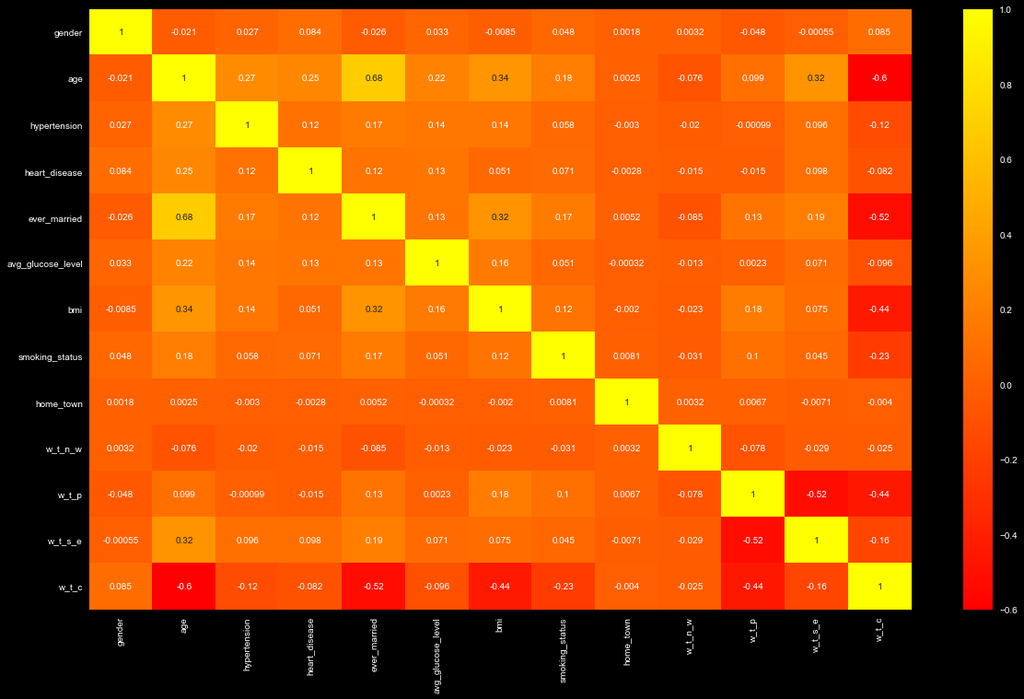

```python
plt.rcParams['figure.figsize'] = (20,12)
corr = mercury.corr()
sns.heatmap(corr, annot=True, cmap='autumn')
plt.show()
```

Function to select the best features with some threshold value.

```python
def correlation(dataset,threshold):
    corr_list = []
    corr_matrix = dataset.corr()
    for i in range(len(corr_matrix.columns)):
        for j in range(i):
            if abs(corr_matrix.iloc[i,j] > threshold):
                column = corr_matrix.columns[[i,j]]
                corr_list.append(column)
    print(len(corr_list))
    return corr_list
correlation(mercury,0.6)
```

```
1
```

```
[Index(['ever_married', 'age'], dtype='object')]
```

Although, we can see ['ever_married', 'age'] are somewhat correlated, but where as if we use 'Variance Inflation Factor", we ended up with fixing the Multicollinearirty.

variance_inflation_factor -> it is used to remove multicollinearity between variables by removing as few variables as possible.

#### VIF->Variance Inflation Factor

```python
vif = variance_inflation_factor
earth1 = pd.Series([vif(mercury.values, i) for i in range(mercury.shape[1])], index = mercury.columns)
earth1
```

```
gender               1.022118
age                  2.637361
hypertension         1.098485
heart_disease        1.096197
ever_married         1.950928
avg_glucose_level    1.081189
bmi                  1.287565
smoking_status       1.069008
home_town            1.000213
w_t_n_w              1.051573
w_t_p                2.336830
w_t_s_e              1.949642
w_t_c                2.712860
dtype: float64
```

Function to check and remove multicollinearity between independent variables.

```python
def mc(data):
  earth = pd.Series([vif(data.values, i) for i in range(data.shape[1])], index = data.columns)
  if earth.max() > 6:
    print(earth[earth == earth.max()].index[0], 'Has Been Removed.')
    data = data.drop(columns = earth[earth == earth.max()].index[0])
  else:
    print("MultiCollinearity Has Been Removed.")
    return data
```

```python
for i in range(5):
  mercury = mc(mercury)
mercury.head()
```

```
MultiCollinearity Has Been Removed.
MultiCollinearity Has Been Removed.
MultiCollinearity Has Been Removed.
MultiCollinearity Has Been Removed.
MultiCollinearity Has Been Removed.
```

|  | gender | age | hypertension | heart_disease | ever_married | avg_glucose_level | bmi | smoking_status | home_town | w_t_n_w | w_t_p | w_t_s_e | w_t_c |
| --- | --- | --- | --- | --- | --- | --- | --- | --- | --- | --- | --- | --- | --- |
| 0 | 1.208899 | -1.830699 | -0.319325 | -0.22194 | -1.379732 | -0.184761 | -1.513815 | -0.647332 | -1.001625 | -0.065637 | -1.190685 | -0.435028 | 2.675967 |
| 1 | 1.208899 | 0.686629 | 3.131608 | -0.22194 | 0.724779 | -0.363905 | 1.539898 | -0.647332 | 0.998378 | -0.065637 | 0.839853 | -0.435028 | -0.373697 |
| 2 | -0.825374 | -1.601851 | -0.319325 | -0.22194 | -1.379732 | 0.209805 | -1.571433 | -0.647332 | 0.998378 | -0.065637 | 0.839853 | -0.435028 | -0.373697 |
| 3 | -0.825374 | 1.235865 | -0.319325 | -0.22194 | 0.724779 | -0.837285 | 1.064556 | 0.690823 | -1.001625 | -0.065637 | 0.839853 | -0.435028 | -0.373697 |
| 4 | 1.208899 | -1.327233 | -0.319325 | -0.22194 | -1.379732 | 1.470566 | -1.355368 | -0.647332 | -1.001625 | 15.235255 | -1.190685 | -0.435028 | -0.373697 |

### **Splitting Data**

Splitting the dataset

1. target_var
2. Independent_var

```python
target_var = camero['stroke']
inde_vars = camero.drop(columns=['stroke'], axis = 1)
```

```python
target_var
```

```
0        0
1        0
2        0
3        0
4        0
        ..
43394    0
43395    0
43397    0
43398    0
43399    0
Name: stroke, Length: 41261, dtype: int64
```

```python
inde_vars.head()
```

|  | gender | age | hypertension | heart_disease | ever_married | avg_glucose_level | bmi | smoking_status | home_town | w_t_n_w | w_t_p | w_t_s_e | w_t_c |
| --- | --- | --- | --- | --- | --- | --- | --- | --- | --- | --- | --- | --- | --- |
| 0 | 2 | 3.0 | 0 | 0 | 0 | 95.12 | 18.0 | 0 | 0 | 0 | 0 | 0 | 1 |
| 1 | 2 | 58.0 | 1 | 0 | 1 | 87.96 | 39.2 | 0 | 1 | 0 | 1 | 0 | 0 |
| 2 | 1 | 8.0 | 0 | 0 | 0 | 110.89 | 17.6 | 0 | 1 | 0 | 1 | 0 | 0 |
| 3 | 1 | 70.0 | 0 | 0 | 1 | 69.04 | 35.9 | 1 | 0 | 0 | 1 | 0 | 0 |
| 4 | 2 | 14.0 | 0 | 0 | 0 | 161.28 | 19.1 | 0 | 0 | 1 | 0 | 0 | 0 |

### **Handling Imbalanced Dataset.**

As we saw the target_calss was highly imbalanced, so we try to balance the target_class using Oversampling method, using "SMOTETomek" tool.

```python
camero.head()
```

|  | gender | age | hypertension | heart_disease | ever_married | avg_glucose_level | bmi | smoking_status | stroke | home_town | w_t_n_w | w_t_p | w_t_s_e | w_t_c |
| --- | --- | --- | --- | --- | --- | --- | --- | --- | --- | --- | --- | --- | --- | --- |
| 0 | 2 | 3.0 | 0 | 0 | 0 | 95.12 | 18.0 | 0 | 0 | 0 | 0 | 0 | 0 | 1 |
| 1 | 2 | 58.0 | 1 | 0 | 1 | 87.96 | 39.2 | 0 | 0 | 1 | 0 | 1 | 0 | 0 |
| 2 | 1 | 8.0 | 0 | 0 | 0 | 110.89 | 17.6 | 0 | 0 | 1 | 0 | 1 | 0 | 0 |
| 3 | 1 | 70.0 | 0 | 0 | 1 | 69.04 | 35.9 | 1 | 0 | 0 | 0 | 1 | 0 | 0 |
| 4 | 2 | 14.0 | 0 | 0 | 0 | 161.28 | 19.1 | 0 | 0 | 0 | 1 | 0 | 0 | 0 |

#### SMOTETomek Tool

```python
so = SMOTETomek()
x_resample,y_resample = so.fit_sample(inde_vars, target_var.values.ravel())
brad = pd.DataFrame(data=x_resample, columns = inde_vars.columns)
```

```python
#Before resampling
print("Before Resampling Target_Variable: ")
print(target_var.value_counts())

# After resampling
y_resample = pd.DataFrame(y_resample)
print("After Resampling Target_Variable:")
print(y_resample[0].value_counts())
```

```
Before Resampling Target_Variable:
0    40517
1      744
Name: stroke, dtype: int64
After Resampling Target_Variable:
1    40470
0    40470
Name: 0, dtype: int64
```

### **Train Test Split.**

Splitting the data into train and test datasets.

```python
x_train,x_test,y_train,y_test = train_test_split(x_resample, y_resample, test_size = 0.3, random_state = 50)
print(x_train.shape)
print(y_train.shape)
print(x_test.shape)
print(y_test.shape)
```

```
(56658, 13)
(56658, 1)
(24282, 13)
(24282, 1)
```

### **Feature Scaling Balanced Data.**

Now, as we have balanced our data, we need to perform feature scaling to the banlanced data.

```python
x_train_ss = se.fit_transform(x_train)
x_test_ss = se.transform(x_test)
```

## **Creating Test Data.**

```python
ford = pd.read_csv("healthcare-dataset-stroke-data.csv")
```

```python
ford.head()
```

|  | id | gender | age | hypertension | heart_disease | ever_married | work_type | Residence_type | avg_glucose_level | bmi | smoking_status | stroke |
| --- | --- | --- | --- | --- | --- | --- | --- | --- | --- | --- | --- | --- |
| 0 | 9046 | Male | 67.0 | 0 | 1 | Yes | Private | Urban | 228.69 | 36.6 | formerly smoked | 1 |
| 1 | 51676 | Female | 61.0 | 0 | 0 | Yes | Self-employed | Rural | 202.21 | NaN | never smoked | 1 |
| 2 | 31112 | Male | 80.0 | 0 | 1 | Yes | Private | Rural | 105.92 | 32.5 | never smoked | 1 |
| 3 | 60182 | Female | 49.0 | 0 | 0 | Yes | Private | Urban | 171.23 | 34.4 | smokes | 1 |
| 4 | 1665 | Female | 79.0 | 1 | 0 | Yes | Self-employed | Rural | 174.12 | 24.0 | never smoked | 1 |

```python
ford.info()
```

```
<class 'pandas.core.frame.DataFrame'>
RangeIndex: 5110 entries, 0 to 5109
Data columns (total 12 columns):
 #   Column             Non-Null Count  Dtype
---  ------             --------------  -----
 0   id                 5110 non-null   int64
 1   gender             5110 non-null   object
 2   age                5110 non-null   float64
 3   hypertension       5110 non-null   int64
 4   heart_disease      5110 non-null   int64
 5   ever_married       5110 non-null   object
 6   work_type          5110 non-null   object
 7   Residence_type     5110 non-null   object
 8   avg_glucose_level  5110 non-null   float64
 9   bmi                4909 non-null   float64
 10  smoking_status     5110 non-null   object
 11  stroke             5110 non-null   int64
dtypes: float64(3), int64(4), object(5)
memory usage: 479.2+ KB
```

```python
ford.drop(index = ford[(ford.age > 1.0) & (ford.age < 2.0)].index, axis = 0, inplace = True)
```

```python
ford.info()
```

```
<class 'pandas.core.frame.DataFrame'>
Int64Index: 5038 entries, 0 to 5109
Data columns (total 12 columns):
 #   Column             Non-Null Count  Dtype
---  ------             --------------  -----
 0   id                 5038 non-null   int64
 1   gender             5038 non-null   object
 2   age                5038 non-null   float64
 3   hypertension       5038 non-null   int64
 4   heart_disease      5038 non-null   int64
 5   ever_married       5038 non-null   object
 6   work_type          5038 non-null   object
 7   Residence_type     5038 non-null   object
 8   avg_glucose_level  5038 non-null   float64
 9   bmi                4842 non-null   float64
 10  smoking_status     5038 non-null   object
 11  stroke             5038 non-null   int64
dtypes: float64(3), int64(4), object(5)
memory usage: 511.7+ KB
```

```python
ford.shape
```

```
(5038, 12)
```

```python
anamolies = []
def outliers(data):
  random_state_mean = np.mean(data)
  random_state_std = np.std(data)
  anamoly = random_state_std * 3

  upper_limit = random_state_mean + anamoly
  lower_limit = random_state_mean - anamoly
  uu =  max(ford['avg_glucose_level'])
  ll = min(ford['avg_glucose_level'])

  print(upper_limit)
  print(lower_limit)
  for i in data:
    if i < ll or i > uu:
      anamolies.append(i)
```

```python
outliers(ford['avg_glucose_level'])
print(len(anamolies))
```

```
242.64307272917313
-30.033838906227473
0
```

```python
dodge['avg_glucose_level'].describe()
```

```
count    41261.000000
mean       102.504529
std         39.968402
min         55.000000
25%         77.370000
50%         91.170000
75%        110.770000
max        234.380000
Name: avg_glucose_level, dtype: float64
```

```python
anamolies = []
def outliers(data):
  random_state_mean = np.mean(data)
  random_state_std = np.std(data)
  anamoly = random_state_std * 3

  upper_limit = random_state_mean + anamoly
  lower_limit = random_state_mean - anamoly
  ll = min(ford['bmi'])

  print(upper_limit)
  print(lower_limit)
  for i in data:
    if i < ll or i > upper_limit:
      anamolies.append(i)
```

```python
outliers(ford['bmi'])
print(len(anamolies))
```

```
52.45615973942819
5.616289661645759
58
```

```python
ford[ford['bmi'] > 52.45615973942819]
```

|  | id | gender | age | hypertension | heart_disease | ever_married | work_type | Residence_type | avg_glucose_level | bmi | smoking_status | stroke |
| --- | --- | --- | --- | --- | --- | --- | --- | --- | --- | --- | --- | --- |
| 113 | 41069 | Female | 45.0 | 0 | 0 | Yes | Private | Rural | 224.10 | 56.6 | never smoked | 1 |
| 258 | 28674 | Female | 74.0 | 1 | 0 | Yes | Self-employed | Urban | 205.84 | 54.6 | never smoked | 0 |
| 270 | 72911 | Female | 57.0 | 1 | 0 | Yes | Private | Rural | 129.54 | 60.9 | smokes | 0 |
| 333 | 1703 | Female | 52.0 | 0 | 0 | Yes | Private | Urban | 82.24 | 54.7 | formerly smoked | 0 |
| 358 | 66333 | Male | 52.0 | 0 | 0 | Yes | Self-employed | Urban | 78.40 | 64.8 | never smoked | 0 |
| 430 | 53144 | Female | 52.0 | 0 | 1 | Yes | Private | Urban | 72.79 | 54.7 | never smoked | 0 |
| 466 | 1307 | Female | 61.0 | 1 | 0 | Yes | Private | Rural | 170.05 | 60.2 | smokes | 0 |
| 544 | 545 | Male | 42.0 | 0 | 0 | Yes | Private | Rural | 210.48 | 71.9 | never smoked | 0 |
| 637 | 3130 | Female | 56.0 | 0 | 0 | Yes | Private | Rural | 112.43 | 54.6 | never smoked | 0 |
| 662 | 23551 | Male | 28.0 | 0 | 0 | Yes | Private | Urban | 87.43 | 55.7 | Unknown | 0 |
| 672 | 31145 | Female | 17.0 | 0 | 0 | No | Private | Urban | 67.81 | 55.7 | never smoked | 0 |
| 715 | 3590 | Female | 28.0 | 1 | 0 | No | Private | Rural | 80.40 | 57.5 | never smoked | 0 |
| 761 | 4169 | Female | 37.0 | 0 | 0 | No | Private | Rural | 92.78 | 54.2 | never smoked | 0 |
| 928 | 41097 | Female | 23.0 | 1 | 0 | No | Private | Urban | 70.03 | 78.0 | smokes | 0 |
| 1061 | 8332 | Female | 50.0 | 0 | 0 | Yes | Private | Rural | 206.25 | 53.4 | formerly smoked | 0 |
| 1077 | 15220 | Female | 53.0 | 1 | 0 | Yes | Private | Urban | 87.03 | 55.2 | formerly smoked | 0 |
| 1304 | 6040 | Female | 46.0 | 0 | 0 | No | Private | Rural | 79.63 | 55.0 | Unknown | 0 |
| 1322 | 35913 | Female | 55.0 | 1 | 0 | Yes | Private | Urban | 206.40 | 54.8 | never smoked | 0 |
| 1532 | 19735 | Female | 59.0 | 0 | 0 | Yes | Private | Rural | 79.18 | 52.8 | formerly smoked | 0 |
| 1559 | 37759 | Female | 53.0 | 0 | 0 | Yes | Private | Rural | 72.63 | 66.8 | Unknown | 0 |
| 1564 | 3178 | Female | 25.0 | 0 | 0 | Yes | Private | Rural | 68.78 | 55.1 | formerly smoked | 0 |
| 1584 | 6372 | Female | 32.0 | 0 | 0 | Yes | Private | Urban | 97.14 | 55.9 | never smoked | 0 |
| 1595 | 2898 | Male | 46.0 | 0 | 0 | Yes | Private | Urban | 87.66 | 57.3 | never smoked | 0 |
| 1660 | 8960 | Female | 42.0 | 0 | 0 | No | Self-employed | Rural | 73.41 | 56.0 | smokes | 0 |
| 1898 | 25405 | Male | 62.0 | 0 | 0 | Yes | Govt_job | Urban | 187.52 | 57.7 | never smoked | 0 |
| 2071 | 61242 | Female | 41.0 | 1 | 0 | Yes | Govt_job | Rural | 107.50 | 54.0 | never smoked | 0 |
| 2081 | 5355 | Male | 63.0 | 0 | 0 | Yes | Govt_job | Rural | 231.69 | 56.1 | formerly smoked | 0 |
| 2128 | 56420 | Male | 17.0 | 1 | 0 | No | Private | Rural | 61.67 | 97.6 | Unknown | 0 |
| 2136 | 59745 | Female | 27.0 | 0 | 0 | Yes | Private | Urban | 76.74 | 53.9 | Unknown | 0 |
| 2330 | 32365 | Male | 42.0 | 0 | 0 | Yes | Private | Rural | 89.22 | 53.8 | Unknown | 0 |
| 2441 | 3668 | Female | 65.0 | 0 | 0 | Yes | Govt_job | Urban | 84.47 | 52.7 | smokes | 0 |
| 2545 | 19504 | Female | 66.0 | 0 | 0 | Yes | Private | Rural | 87.84 | 52.8 | Unknown | 0 |
| 2555 | 7171 | Female | 56.0 | 0 | 0 | Yes | Govt_job | Urban | 102.51 | 55.7 | Unknown | 0 |
| 2567 | 65564 | Female | 48.0 | 0 | 0 | Yes | Private | Urban | 57.43 | 53.5 | formerly smoked | 0 |
| 2764 | 20292 | Female | 24.0 | 0 | 0 | Yes | Private | Urban | 85.55 | 63.3 | never smoked | 0 |
| 2815 | 50215 | Male | 42.0 | 0 | 0 | No | Govt_job | Rural | 59.83 | 52.8 | never smoked | 0 |
| 2840 | 65895 | Female | 52.0 | 0 | 0 | Yes | Private | Urban | 98.27 | 61.2 | Unknown | 0 |
| 3060 | 32604 | Male | 49.0 | 0 | 0 | Yes | Self-employed | Rural | 215.81 | 58.1 | never smoked | 0 |
| 3243 | 11111 | Female | 66.0 | 1 | 0 | Yes | Govt_job | Urban | 205.01 | 52.7 | formerly smoked | 0 |
| 3508 | 65154 | Female | 30.0 | 0 | 0 | Yes | Private | Urban | 112.19 | 53.4 | never smoked | 0 |
| 3588 | 23047 | Male | 43.0 | 0 | 0 | Yes | Private | Urban | 100.16 | 59.7 | never smoked | 0 |
| 3606 | 14872 | Male | 45.0 | 1 | 0 | Yes | Self-employed | Rural | 239.19 | 52.5 | Unknown | 0 |
| 3688 | 38575 | Male | 58.0 | 1 | 0 | Yes | Self-employed | Rural | 209.15 | 52.9 | formerly smoked | 0 |
| 3702 | 7730 | Male | 31.0 | 0 | 0 | No | Private | Rural | 94.96 | 54.7 | smokes | 0 |
| 3825 | 72784 | Female | 52.0 | 0 | 0 | Yes | Private | Rural | 118.46 | 61.6 | smokes | 0 |
| 3909 | 4077 | Male | 49.0 | 0 | 0 | Yes | Private | Urban | 219.70 | 53.8 | Unknown | 0 |
| 3931 | 27660 | Female | 73.0 | 1 | 0 | No | Self-employed | Rural | 198.30 | 54.3 | formerly smoked | 0 |
| 3980 | 11192 | Female | 45.0 | 0 | 0 | Yes | Private | Rural | 218.10 | 55.0 | smokes | 0 |
| 4154 | 47668 | Female | 49.0 | 0 | 0 | Yes | Private | Rural | 125.63 | 57.2 | Unknown | 0 |
| 4188 | 70670 | Female | 27.0 | 0 | 0 | Yes | Private | Rural | 57.96 | 64.4 | never smoked | 0 |
| 4209 | 51856 | Male | 38.0 | 1 | 0 | Yes | Private | Rural | 56.90 | 92.0 | never smoked | 0 |
| 4225 | 14658 | Female | 37.0 | 0 | 0 | Yes | Private | Rural | 77.10 | 55.9 | Unknown | 0 |
| 4351 | 63915 | Female | 39.0 | 0 | 0 | Yes | Private | Urban | 87.39 | 57.9 | never smoked | 0 |
| 4407 | 49277 | Female | 34.0 | 0 | 0 | No | Private | Urban | 70.87 | 55.7 | formerly smoked | 0 |
| 4475 | 60675 | Female | 48.0 | 1 | 0 | Yes | Govt_job | Rural | 221.08 | 57.2 | never smoked | 0 |
| 4838 | 5131 | Female | 51.0 | 0 | 0 | Yes | Private | Urban | 107.72 | 60.9 | Unknown | 0 |
| 4906 | 72696 | Female | 53.0 | 0 | 0 | Yes | Private | Urban | 70.51 | 54.1 | never smoked | 0 |
| 4952 | 16245 | Male | 51.0 | 1 | 0 | Yes | Self-employed | Rural | 211.83 | 56.6 | never smoked | 0 |

```python
ford.drop(index = ford[ford['bmi'] > 52.45615973942819].index, axis = 0, inplace = True)
```

```python
ford.shape
```

```
(4980, 12)
```

```python
ford.isnull().sum()
```

```
id                     0
gender                 0
age                    0
hypertension           0
heart_disease          0
ever_married           0
work_type              0
Residence_type         0
avg_glucose_level      0
bmi                  196
smoking_status         0
stroke                 0
dtype: int64
```

```python
ford['bmi'].mean()
```

```
28.681291806020063
```

```python
ford['bmi'].fillna(ford['bmi'].mean(), inplace = True)
```

```python
ford['bmi'].isnull().sum()
```

```
0
```

```python
ford['smoking_status'].replace('Unknown', 'never smoked')
```

```
0       formerly smoked
1          never smoked
2          never smoked
3                smokes
4          never smoked
             ...
5105       never smoked
5106       never smoked
5107       never smoked
5108    formerly smoked
5109       never smoked
Name: smoking_status, Length: 4980, dtype: object
```

```python
ford.info()
```

```
<class 'pandas.core.frame.DataFrame'>
Int64Index: 4980 entries, 0 to 5109
Data columns (total 12 columns):
 #   Column             Non-Null Count  Dtype
---  ------             --------------  -----
 0   id                 4980 non-null   int64
 1   gender             4980 non-null   object
 2   age                4980 non-null   float64
 3   hypertension       4980 non-null   int64
 4   heart_disease      4980 non-null   int64
 5   ever_married       4980 non-null   object
 6   work_type          4980 non-null   object
 7   Residence_type     4980 non-null   object
 8   avg_glucose_level  4980 non-null   float64
 9   bmi                4980 non-null   float64
 10  smoking_status     4980 non-null   object
 11  stroke             4980 non-null   int64
dtypes: float64(3), int64(4), object(5)
memory usage: 505.8+ KB
```

```python
ford.drop(columns = ['id'], axis=1, inplace = True)
```

```python
ford['smoking_status'].replace({'Unknown':'never smoked'}, inplace = True)
```

```python
ford['gender'] = ford['gender'].map(mapping)
```

```python
ford['ever_married'] = ford['ever_married'].map(mapping1)
```

```python
ford['smoking_status'] = ford['smoking_status'].map(mapping2)
```

```python
ford[['gender', 'smoking_status', 'ever_married']].head()
```

|  | gender | smoking_status | ever_married |
| --- | --- | --- | --- |
| 0 | 2 | 1 | 1 |
| 1 | 1 | 0 | 1 |
| 2 | 2 | 0 | 1 |
| 3 | 1 | 2 | 1 |
| 4 | 1 | 0 | 1 |

```python
ford['work_type'].unique()
```

```
array(['Private', 'Self-employed', 'Govt_job', 'children', 'Never_worked'],
      dtype=object)
```

```python
ford['Residence_type'].unique()
```

```
array(['Urban', 'Rural'], dtype=object)
```

```python
ford['home_town'] = pd.get_dummies(ford['Residence_type'], drop_first = True)
```

```python
rap = pd.get_dummies(ford['work_type'], drop_first = True)
```

```python
cam = pd.concat([ford,rap], axis = 1)
```

```python
cam.head()
```

|  | gender | age | hypertension | heart_disease | ever_married | work_type | Residence_type | avg_glucose_level | bmi | smoking_status | stroke | home_town | Never_worked | Private | Self-employed | children |
| --- | --- | --- | --- | --- | --- | --- | --- | --- | --- | --- | --- | --- | --- | --- | --- | --- |
| 0 | 2 | 67.0 | 0 | 1 | 1 | Private | Urban | 228.69 | 36.600000 | 1 | 1 | 1 | 0 | 1 | 0 | 0 |
| 1 | 1 | 61.0 | 0 | 0 | 1 | Self-employed | Rural | 202.21 | 28.681292 | 0 | 1 | 0 | 0 | 0 | 1 | 0 |
| 2 | 2 | 80.0 | 0 | 1 | 1 | Private | Rural | 105.92 | 32.500000 | 0 | 1 | 0 | 0 | 1 | 0 | 0 |
| 3 | 1 | 49.0 | 0 | 0 | 1 | Private | Urban | 171.23 | 34.400000 | 2 | 1 | 1 | 0 | 1 | 0 | 0 |
| 4 | 1 | 79.0 | 1 | 0 | 1 | Self-employed | Rural | 174.12 | 24.000000 | 0 | 1 | 0 | 0 | 0 | 1 | 0 |

```python
cam.rename(columns = {'Never_worked':'w_t_n_w', 'Private':'w_t_p', 'Self-employed':'w_t_s_e', 'children':'w_t_c'}, inplace = True)
```

```python
cam.drop(columns = ['work_type','Residence_type'], inplace = True)
```

```python
target = cam['stroke']
original = cam.drop(columns = ['stroke'])
```

```python
resampled_x,resampled_y = so.fit_resample(original,target.values.ravel())
pitt = pd.DataFrame(data = resampled_x, columns=original.columns)
```

```python
#Before resampling
print("Before Resampling Target_Variable: ")
print(target.value_counts())

# After resampling
resampled_y = pd.DataFrame(resampled_y)
print("After Resampling Target_Variable:")
print(resampled_y[0].value_counts())
```

```
Before Resampling Target_Variable:
0    4733
1     247
Name: stroke, dtype: int64
After Resampling Target_Variable:
1    4685
0    4685
Name: 0, dtype: int64
```

```python
fish = se.fit_transform(resampled_x)
lucas = pd.DataFrame(data = fish, columns = original.columns)
```

```python
lucas.head()
```

|  | gender | age | hypertension | heart_disease | ever_married | avg_glucose_level | bmi | smoking_status | home_town | w_t_n_w | w_t_p | w_t_s_e | w_t_c |
| --- | --- | --- | --- | --- | --- | --- | --- | --- | --- | --- | --- | --- | --- |
| 0 | 1.439490 | 0.527117 | -0.308237 | 4.467882 | 0.613451 | 1.981290 | 1.207034 | 0.887229 | 1.201633 | -0.048512 | 1.046323 | -0.374406 | -0.265039 |
| 1 | -0.694015 | 0.251840 | -0.308237 | -0.223820 | 0.613451 | 1.502107 | -0.094405 | -0.619629 | -0.832201 | -0.048512 | -0.955728 | 2.670895 | -0.265039 |
| 2 | 1.439490 | 1.123550 | -0.308237 | 4.467882 | 0.613451 | -0.240362 | 0.533199 | -0.619629 | -0.832201 | -0.048512 | 1.046323 | -0.374406 | -0.265039 |
| 3 | -0.694015 | -0.298714 | -0.308237 | -0.223820 | 0.613451 | 0.941491 | 0.845464 | 2.394087 | 1.201633 | -0.048512 | 1.046323 | -0.374406 | -0.265039 |
| 4 | -0.694015 | 1.077670 | 3.244259 | -0.223820 | 0.613451 | 0.993789 | -0.863775 | -0.619629 | -0.832201 | -0.048512 | -0.955728 | 2.670895 | -0.265039 |

```python
lucas.info()
```

```
<class 'pandas.core.frame.DataFrame'>
RangeIndex: 9370 entries, 0 to 9369
Data columns (total 13 columns):
 #   Column             Non-Null Count  Dtype
---  ------             --------------  -----
 0   gender             9370 non-null   float64
 1   age                9370 non-null   float64
 2   hypertension       9370 non-null   float64
 3   heart_disease      9370 non-null   float64
 4   ever_married       9370 non-null   float64
 5   avg_glucose_level  9370 non-null   float64
 6   bmi                9370 non-null   float64
 7   smoking_status     9370 non-null   float64
 8   home_town          9370 non-null   float64
 9   w_t_n_w            9370 non-null   float64
 10  w_t_p              9370 non-null   float64
 11  w_t_s_e            9370 non-null   float64
 12  w_t_c              9370 non-null   float64
dtypes: float64(13)
memory usage: 951.8 KB
```

## **Decision Tree Classifier**

```python
from sklearn.tree import DecisionTreeClassifier
dt = DecisionTreeClassifier()
dt.fit(x_train_ss,y_train)
predictions = dt.predict(x_test_ss)

print('The Training Accuracy of x_train and y_train is', dt.score(x_train_ss,y_train))
print("The Testing Accuracy of x_test and y_test is", dt.score(x_test_ss,y_test))
```

```
The Training Accuracy of x_train and y_train is 1.0
The Testing Accuracy of x_test and y_test is 0.953751750267688
```

```python
print(confusion_matrix(predictions,y_test))
```

```
[[11463   459]
 [  664 11696]]
```

```python
print(classification_report(predictions,y_test))
```

```
              precision    recall  f1-score   support

           0       0.95      0.96      0.95     11922
           1       0.96      0.95      0.95     12360

    accuracy                           0.95     24282
   macro avg       0.95      0.95      0.95     24282
weighted avg       0.95      0.95      0.95     24282
```

```python
print(accuracy_score(predictions, y_test))
```

```
0.953751750267688
```

### **Tree Plot.**

```
[Text(266.3129478253746, 535.3636363636364, 'X[1] <= -0.253\ngini = 0.5\nsamples = 56658\nvalue = [28343, 28315]'),
 ...]
```

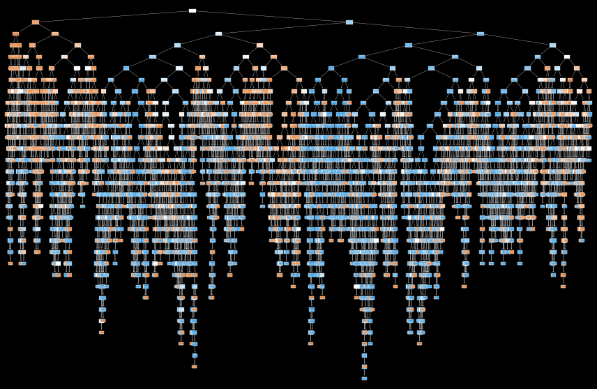

```python
plt.figure(figsize = (15,10))
tree.plot_tree(dt, filled = True)
```

### Performing Cross Validation on DT Model.

Performing cross validation on the dataset using StratifiedKFold and calculating the mean Accuracy that can be achieved by the model.

```python
x = pd.DataFrame(data = x_train_ss, columns = inde_vars.columns)
y = y_train
from sklearn.model_selection import  StratifiedKFold
accuracy = []
skf = StratifiedKFold(n_splits = 10, random_state = None)
skf.get_n_splits(x,y)
for train_index, test_index in skf.split(x,y):
  print('Train:', train_index, 'Validation',test_index)
  x1_train,x1_test = x.iloc[train_index],x.iloc[test_index]
  y1_train,y1_test = y.iloc[train_index],y.iloc[test_index]
  dt.fit(x1_train,y1_train)
  pred = dt.predict(x1_test)
  score = accuracy_score(pred,y1_test)
  accuracy.append(score)
print(accuracy)
```

```
Train: [ 5595  5596  5597 ... 56655 56656 56657] Validation [   0    1    2 ... 5749 5750 5752]
Train: [    0     1     2 ... 56655 56656 56657] Validation [ 5595  5596  5597 ... 11348 11351 11352]
Train: [    0     1     2 ... 56655 56656 56657] Validation [11305 11306 11308 ... 17019 17022 17024]
Train: [    0     1     2 ... 56655 56656 56657] Validation [16980 16983 16984 ... 22681 22685 22689]
Train: [    0     1     2 ... 56655 56656 56657] Validation [22637 22642 22646 ... 28498 28499 28500]
Train: [    0     1     2 ... 56655 56656 56657] Validation [28164 28165 28166 ... 34208 34210 34211]
Train: [    0     1     2 ... 56655 56656 56657] Validation [33785 33786 33788 ... 39838 39839 39840]
Train: [    0     1     2 ... 56655 56656 56657] Validation [39486 39487 39490 ... 45432 45434 45435]
Train: [    0     1     2 ... 56655 56656 56657] Validation [45222 45224 45226 ... 51006 51007 51008]
Train: [    0     1     2 ... 51006 51007 51008] Validation [50979 50980 50981 ... 56655 56656 56657]
[0.9532297917402047, 0.9417578538651606, 0.952347334980586, 0.9528768090363572, 0.9514648782209671, 0.9505824214613484, 0.9511118955171196, 0.9505824214613484, 0.9525154457193292, 0.9526919682259488]
```

```python
arr = np.array(accuracy)
```

```python
np.mean(arr)
```

```
0.9509160820228371
```

### Hyper Parameter Tuning the model to overcome Overfitting model.

Determining the parameters by plotting f1_score metrics.

1. Function to calculate f1_score.
2. Function to plot the f1_score that we have calculated.
3. Pass the parameter values in the model and call the functions.

```python
def cal_score(model, x1,y1,x2,y2):
  model.fit(x1,y1)
  p = model.predict(x1)
  f1 = f1_score(y1, p)
  p1 = model.predict(x2)
  f2 = f1_score(y2,p1)
  return f1,f2
```

```python
def effect(train, test, x_axis, title):
  plt.figure(figsize = (12,10), dpi = 100)
  plt.plot(x_axis, train, color = 'red', label = 'train_score')
  plt.plot(x_axis, test, color = 'blue', label = 'test_score')
  plt.legend()
  plt.show()
```

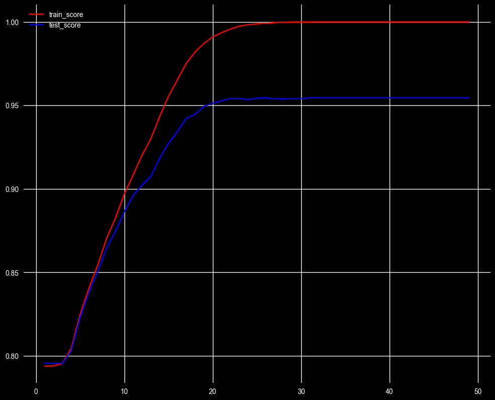

```python
max_depth = [i for i in range(1,50)]
train = []
test = []
for i in max_depth:
  model =DecisionTreeClassifier(max_depth=i, random_state=50)
  f1,f2 = cal_score(model, x_train, y_train, x_test, y_test)
  train.append(f1)
  test.append(f2)
effect(train,test, range(1,50), 'Max_Depth')
```

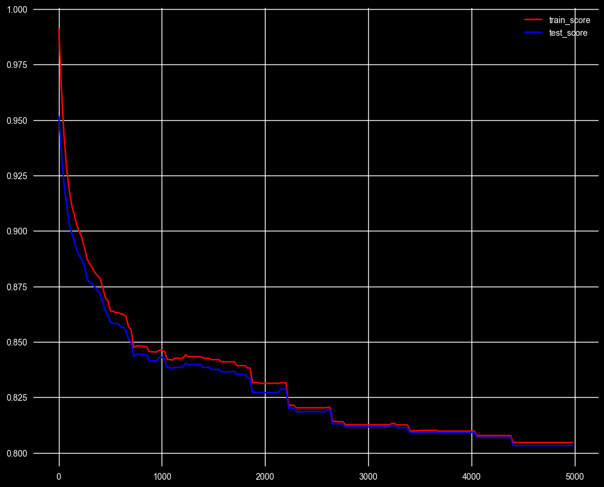

```python
min_samples = [i for i in range(2,5000,25)]
train = []
test = []
for i in min_samples:
  model =DecisionTreeClassifier(max_depth=20, random_state=50, min_samples_split=i)
  f1,f2 = cal_score(model, x_train, y_train, x_test, y_test)
  train.append(f1)
  test.append(f2)
effect(train,test, range(2,5000,25), 'Min_Samples_Split')
```

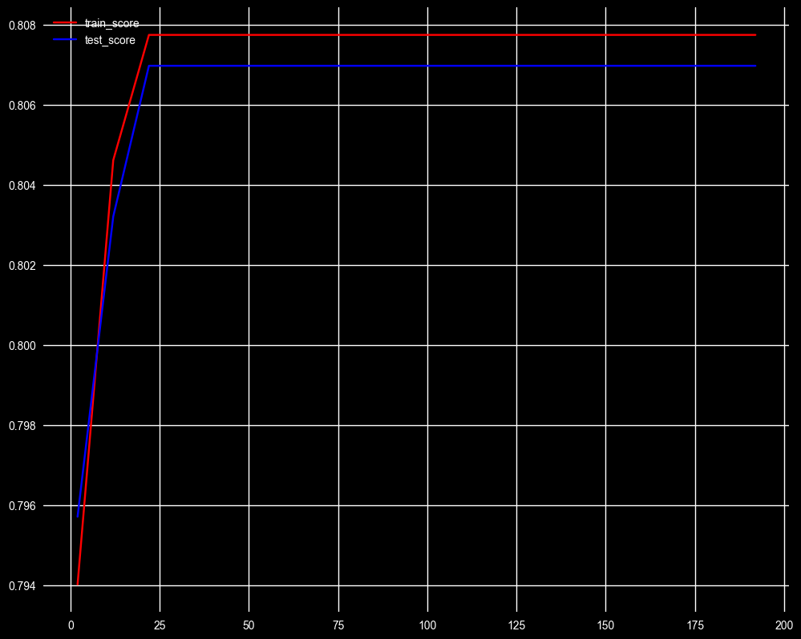

```python
max_leaf = [i for i in range(2,200,10)]
train = []
test = []
for i in max_leaf:
  model =DecisionTreeClassifier(max_depth=20,min_samples_split=4250,max_leaf_nodes=i, random_state=50)
  f1,f2 = cal_score(model, x_train, y_train, x_test, y_test)
  train.append(f1)
  test.append(f2)
effect(train,test, range(2,200,10), 'Max_Leaf_Nodes')
```

### Hyper Parameter Tuning the model by using roc_auc_curve.

```python
def cal_score1(model, x1,y1,x2,y2):
  model.fit(x1,y1)
  p = model.predict(x1)
  false_positive_rate, true_positive_rate, thresholds = roc_curve(y1, p)
  roc_auc_1 = auc(false_positive_rate, true_positive_rate)
  p1 = model.predict(x2)
  false_positive_rate, true_positive_rate, thresholds = roc_curve(y2, p1)
  roc_auc_2 = auc(false_positive_rate, true_positive_rate)
  return roc_auc_1,roc_auc_2
```

```python
def effect1(train, test, x_axis, title):
  plt.figure(figsize = (12,10), dpi = 100)
  plt.plot(x_axis, train, color = 'red', label = 'train_score')
  plt.plot(x_axis, test, color = 'blue', label = 'test_score')
  plt.legend()
  plt.show()
```

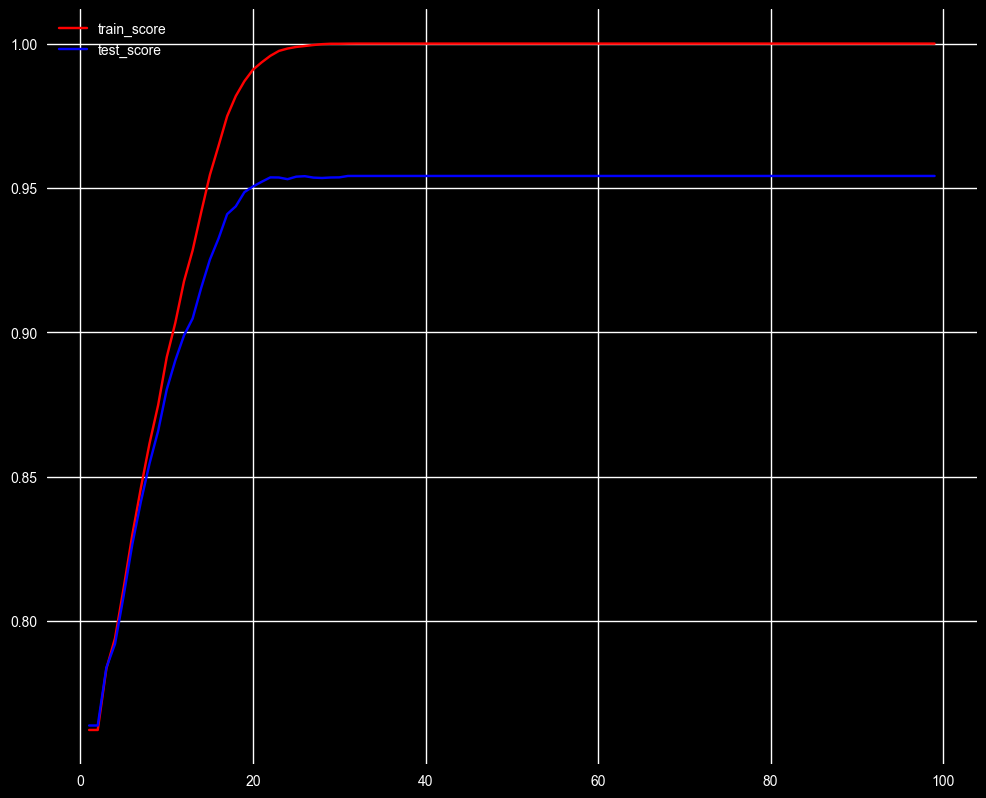

```python
max_depth = [i for i in range(1,100)]
train = []
test = []
for i in max_depth:
  roc_auc_model =DecisionTreeClassifier(max_depth=i, random_state=50)
  roc_auc_1,roc_auc_2 = cal_score1(roc_auc_model, x_train, y_train, x_test, y_test)
  train.append(roc_auc_1)
  test.append(roc_auc_2)
effect1(train,test, range(1,100), 'Max_Depth')
```

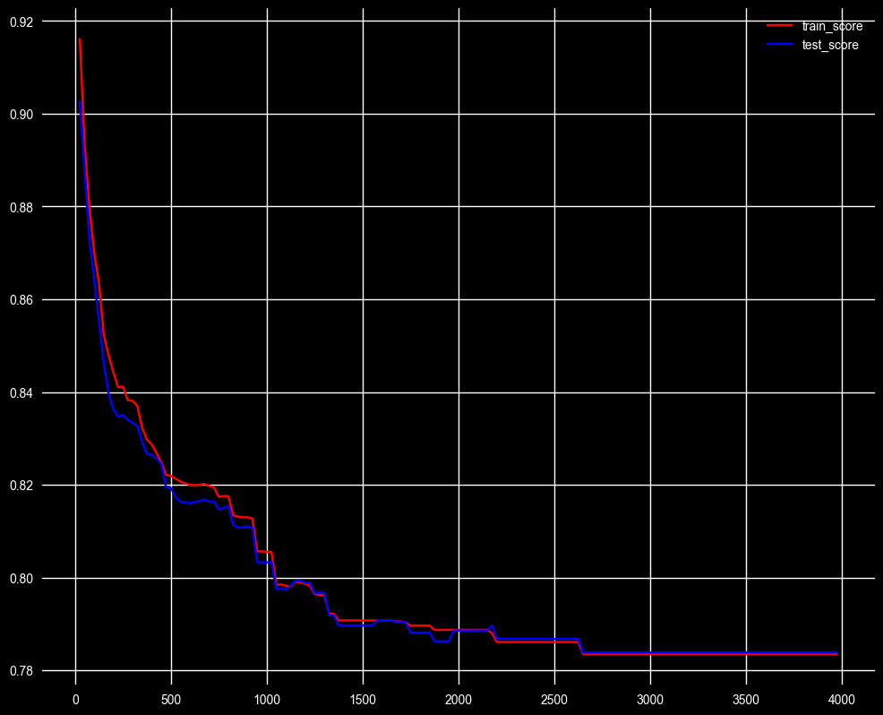

```python
min_sample_leaff = [i for i in range(25,4000,25)]
train = []
test = []
for i in min_sample_leaff:
  roc_auc_model =DecisionTreeClassifier(max_depth=20, min_samples_leaf=i, random_state=50)
  roc_auc_1,roc_auc_2 = cal_score1(roc_auc_model, x_train, y_train, x_test, y_test)
  train.append(roc_auc_1)
  test.append(roc_auc_2)
effect1(train,test, range(25,4000,25), 'Min_Samples_Leaf')
```

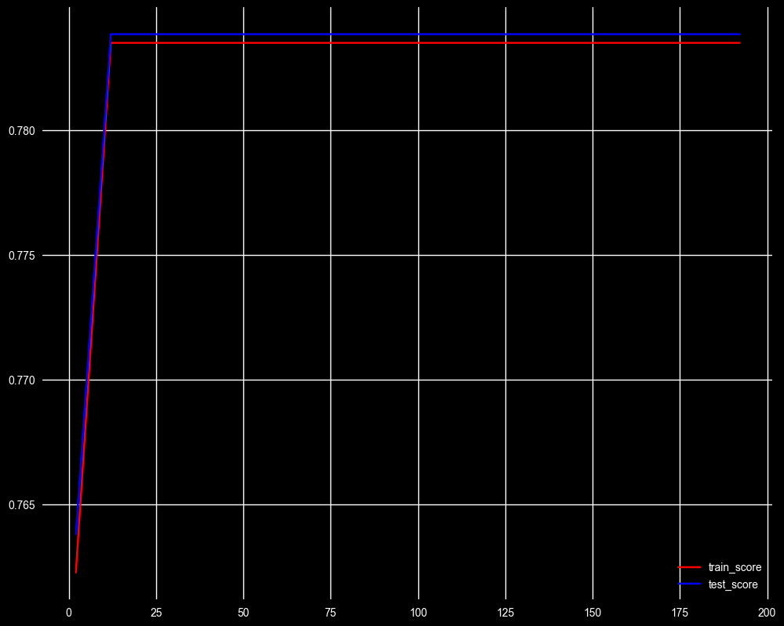

```python
max_leaf_node = [i for i in range(2,200,10)]
train = []
test = []
for i in max_leaf_node:
  roc_auc_model =DecisionTreeClassifier(max_depth=20,max_leaf_nodes=i, min_samples_leaf=3700, random_state=50)
  roc_auc_1,roc_auc_2 = cal_score1(roc_auc_model, x_train, y_train, x_test, y_test)
  train.append(roc_auc_1)
  test.append(roc_auc_2)
effect1(train,test, range(2,200,10), 'Max_Leaf_Nodes')
```

### Hyper parameter Tuning the model using ccp(cost complexity pruning)

which helps us to select the best values for max_depth and max_samples_leaf parameter for Decision Tree.

```python
path = dt.cost_complexity_pruning_path(x_train_ss,y_train)
ccp_alphas, impurities = path.ccp_alphas, path.impurities
```

```python
ccp_alphas
```

```
array([0.00000000e+00, 1.06968232e-05, 1.10310989e-05, ...,
       9.63635249e-03, 2.11399782e-02, 1.52138383e-01])
```

```python
clfs = []
for i in ccp_alphas:
  dt = DecisionTreeClassifier(random_state = 0, ccp_alpha=i)
  dt.fit(x_train_ss,y_train)
  clfs.append(dt)
  print('Number of Nodes in the Last Tree is: {} with ccp_alpha: {}'.format(clfs[-1].tree_.node_count, ccp_alphas[-1]))
```

[output not shown]

[output cut: 1476 more lines]

[output not shown]

Plotting a graph with Respect to Accuracy score and various clfs(classifiers)

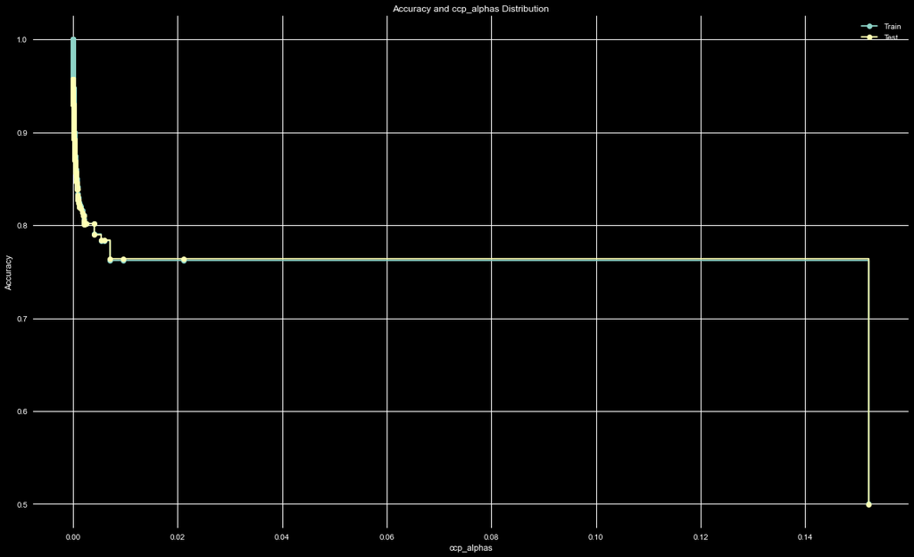

```python
train_set = [dt.score(x_train_ss,y_train) for dt in clfs]
test_set = [dt.score(x_test_ss,y_test) for dt in clfs]

plt.figure(figsize = (12,10), dpi = 100)
fig,ax = plt.subplots()
ax.plot(ccp_alphas, train_set, marker = 'o', label = 'Train', drawstyle = 'steps-post')
ax.plot(ccp_alphas, test_set, marker = 'o', label = 'Test', drawstyle = 'steps-post')
ax.set_xlabel('ccp_alphas')
ax.set_ylabel('Accuracy')
ax.set_title("Accuracy and ccp_alphas Distribution")
ax.legend()
plt.show()
```

So, After applying Hyper Parameter Tuning **With Respect to Evaluation Metrics**, our model has successfully overcomed the problem of overfitting which has occured earlier.

```python
modified_model = DecisionTreeClassifier(max_depth = 18, min_samples_split=4250, min_samples_leaf=3700, max_leaf_nodes=21)
modified_model.fit(x_train_ss, y_train)
pr = modified_model.predict(x_test_ss)
```

```python
print(modified_model.score(x_train_ss,y_train))
print(modified_model.score(x_test_ss, y_test))
print(accuracy_score(pr,y_test))
```

```
0.7834727664231
0.7839140103780579
0.7839140103780579
```

### Tree Plot With Respect to Modified Model.

```
[Text(418.5, 504.7714285714286, 'X[1] <= -0.253\ngini = 0.5\nsamples = 56658\nvalue = [28343, 28315]'),
```

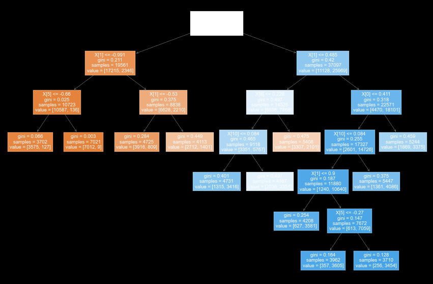

```python
plt.figure(figsize = (15,10))
tree.plot_tree(modified_model, filled = True)
```

### **Evaluating Tuned Model on Test Data.**

```python
hash = modified_model.predict(lucas)
```

```python
print(accuracy_score(hash,resampled_y))
```

```
0.7828175026680897
```

```python
print(classification_report(hash,resampled_y))
```

```
              precision    recall  f1-score   support

           0       0.72      0.82      0.77      4080
           1       0.85      0.75      0.80      5290

    accuracy                           0.78      9370
   macro avg       0.78      0.79      0.78      9370
weighted avg       0.79      0.78      0.78      9370
```

```python
print(confusion_matrix(hash,resampled_y))
```

```
[[3365  715]
 [1320 3970]]
```

```python
print(precision_score(hash, resampled_y))
```

```
0.847385272145144
```

```python
print(recall_score(hash, resampled_y))
```

```
0.7504725897920604
```

```python
print(f1_score(hash, resampled_y))
```

```
0.7959899749373432
```

### Verifying With Respect to ccp_alpha value.

```python
pathh = dt.cost_complexity_pruning_path(x_train_ss,y_train)
ccp_alphass, impurities = path.ccp_alphas, path.impurities
```

```python
clfss = []
for i in ccp_alphass:
  dt = DecisionTreeClassifier(max_depth = 18, min_samples_split=4250, min_samples_leaf=3700, max_leaf_nodes=21, random_state = 0, ccp_alpha=i)
  dt.fit(x_train_ss,y_train)
  clfss.append(dt)
print('Number of Nodes in the Last Tree is: {} with ccp_alpha: {}'.format(clfs[-1].tree_.node_count, ccp_alphas[-1]))
```

```
Number of Nodes in the Last Tree is: 1 with ccp_alpha: 0.15213838336474234
```

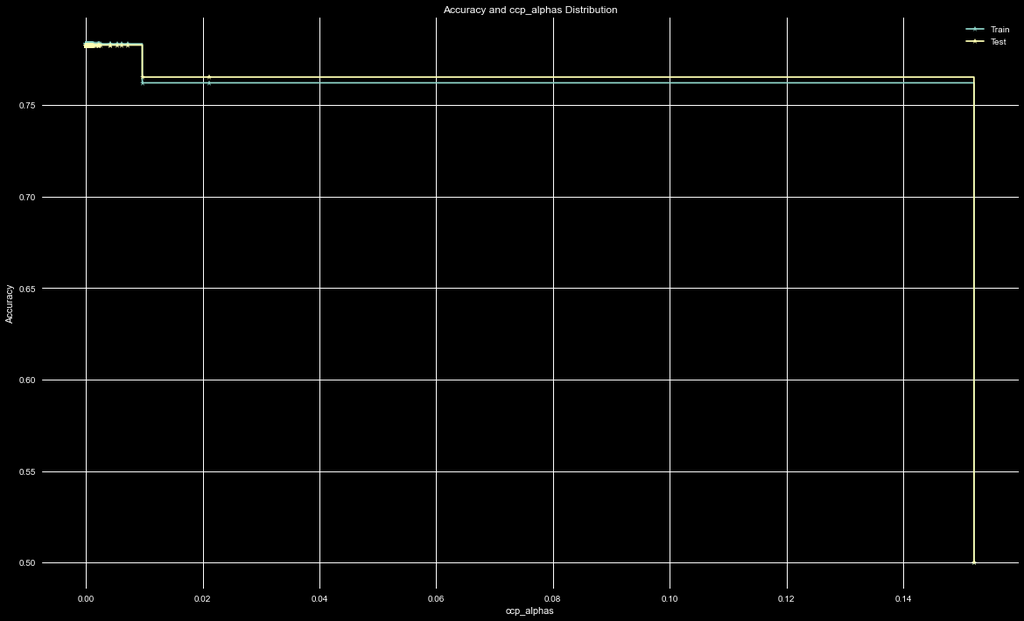

```python
train_sett = [dt.score(x_train_ss,y_train) for dt in clfss]
test_sett = [dt.score(lucas,resampled_y) for dt in clfss]

plt.figure(figsize = (12,10), dpi = 100)
fig,ax = plt.subplots()
ax.plot(ccp_alphass, train_sett, marker = '*', label = 'Train', drawstyle = 'steps-post')
ax.plot(ccp_alphass, test_sett, marker = '*', label = 'Test', drawstyle = 'steps-post')
ax.set_xlabel('ccp_alphas')
ax.set_ylabel('Accuracy')
ax.set_title("Accuracy and ccp_alphas Distribution")
ax.legend()
plt.show()
```

```python
mod_model_ccp = DecisionTreeClassifier(random_state = 0, ccp_alpha = 0.04)
mod_model_ccp.fit(x_train_ss,y_train)
```

```
DecisionTreeClassifier(ccp_alpha=0.04, random_state=0)
```

```python
print(mod_model_ccp.score(x_train_ss,y_train))
print(mod_model_ccp.score(x_test_ss, y_test))
```

```
0.762187158035935
0.76398155011943
```

```python
predicate = mod_model_ccp.predict(lucas)
```

```python
print(accuracy_score(predicate,resampled_y))
```

```
0.7653148345784418
```

```python
print(precision_score(predicate, resampled_y))
```

```
0.9415154749199574
```

```python
print(recall_score(predicate, resampled_y))
```

```
0.6961805555555556
```

```python
print(f1_score(predicate, resampled_y))
```

```
0.8004718265130207
```

### Tree plot with respect to ccp_modified_model

```
[Text(334.8, 407.70000000000005, 'X[1] <= -0.253\ngini = 0.5\nsamples = 56658\nvalue = [28343, 28315]'),
```

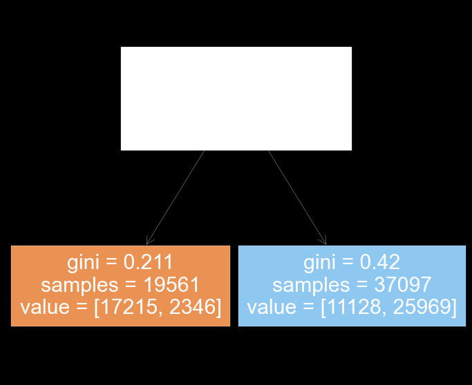

```python
plt.figure(figsize = (12,10))
tree.plot_tree(mod_model_ccp, filled=True)
```

## **Logistic Regression**

```python
from sklearn.linear_model import LogisticRegression
lg = LogisticRegression()
lg.fit(x_train_ss, y_train)
lg_pred = lg.predict(x_test_ss)
predicted_values = lg.predict_proba(x_test_ss)
```

```python
print('Training Accuracy:', lg.score(x_train_ss,y_train))
print('Test Accuracy:', lg.score(x_test_ss,y_test))
```

```
Training Accuracy: 0.8186310847541388
Test Accuracy: 0.8206490404414792
```

```python
recall_score(y_test, lg_pred)
```

```
0.8296174413821472
```

```python
precision_score(y_test,lg_pred)
```

```
0.8153298835705045
```

```python
f1_score(y_test,lg_pred)
```

```
0.8224116135872447
```

```python
y_testt = y_test.squeeze()
```

```python
precision_points, recall_points, threshold_points = precision_recall_curve(y_testt, predicted_values[:,1])
```

```python
precision_points.shape, recall_points.shape, threshold_points.shape
```

```
((22766,), (22766,), (22765,))
```

```python
precision_points
```

```
array([0.53393367, 0.5339132 , 0.53393665, ..., 1.        , 1.        ,
       1.        ])
```

```python
recall_points
```

```
array([1.00000000e+00, 9.99917729e-01, 9.99917729e-01, ...,
       1.64541341e-04, 8.22706705e-05, 0.00000000e+00])
```

```python
threshold_points
```

```
array([2.90483138e-04, 2.91188966e-04, 2.92204193e-04, ...,
       9.94797111e-01, 9.94891745e-01, 9.94912946e-01])
```

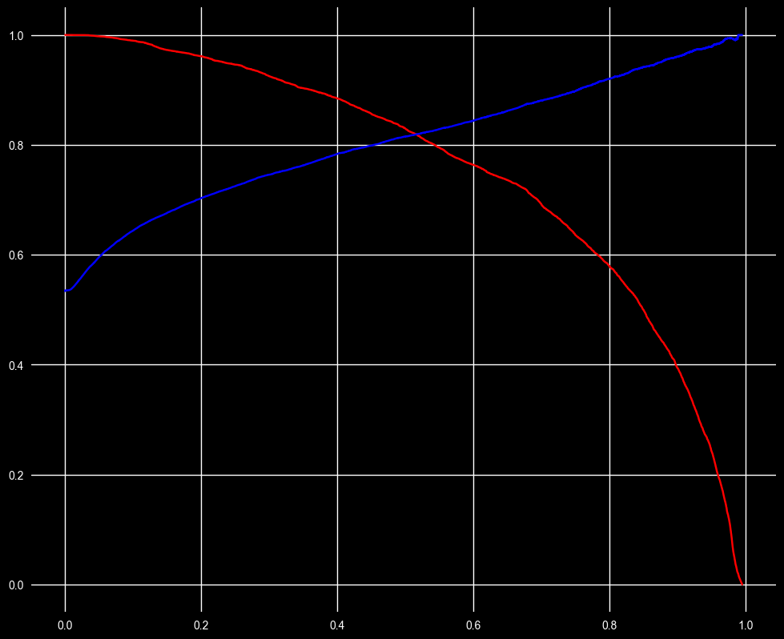

```python
plt.figure(figsize = (12,10), dpi = 100)
plt.plot(threshold_points, recall_points[:-1], color = 'red')
plt.plot(threshold_points, precision_points[:-1], color = 'blue')
plt.show()
```